# Métodos Numéricos Aplicados a Finanças — Turma 2025

## 9.7 Modelo log-log

````
```{r,}
````

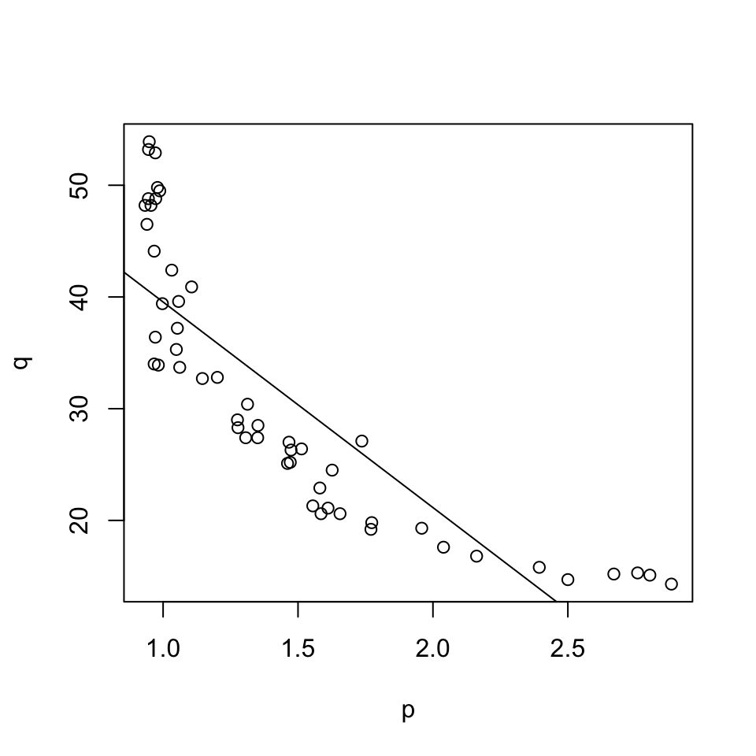

```r
data("newbroiler", package="PoEdata")
mod.a <- lm(q~p, newbroiler)
plot(mod.a$model[,2:1]); abline(mod.a)
```

```r
mod.a$residuals %>% scale %>% shapiro.test()
```

```
##
##  Shapiro-Wilk normality test
##
## data:  .
## W = 0.88678, p-value = 0.0001358
```

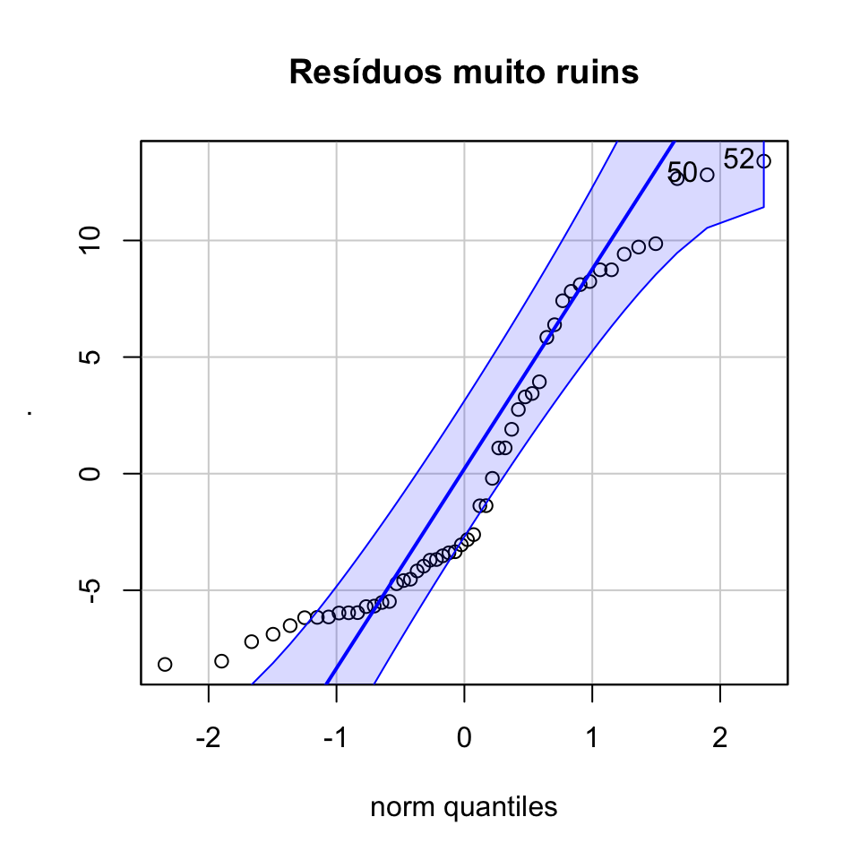

```
## [1] 52 50
```

```r
mod.a$residuals %>% qqPlot(main="Resíduos muito ruins")
```

```r
mod.a %>% reset
```

```
##
##  RESET test
##
## data:  .
## RESET = 41.974, df1 = 2, df2 = 48, p-value = 2.885e-11
```

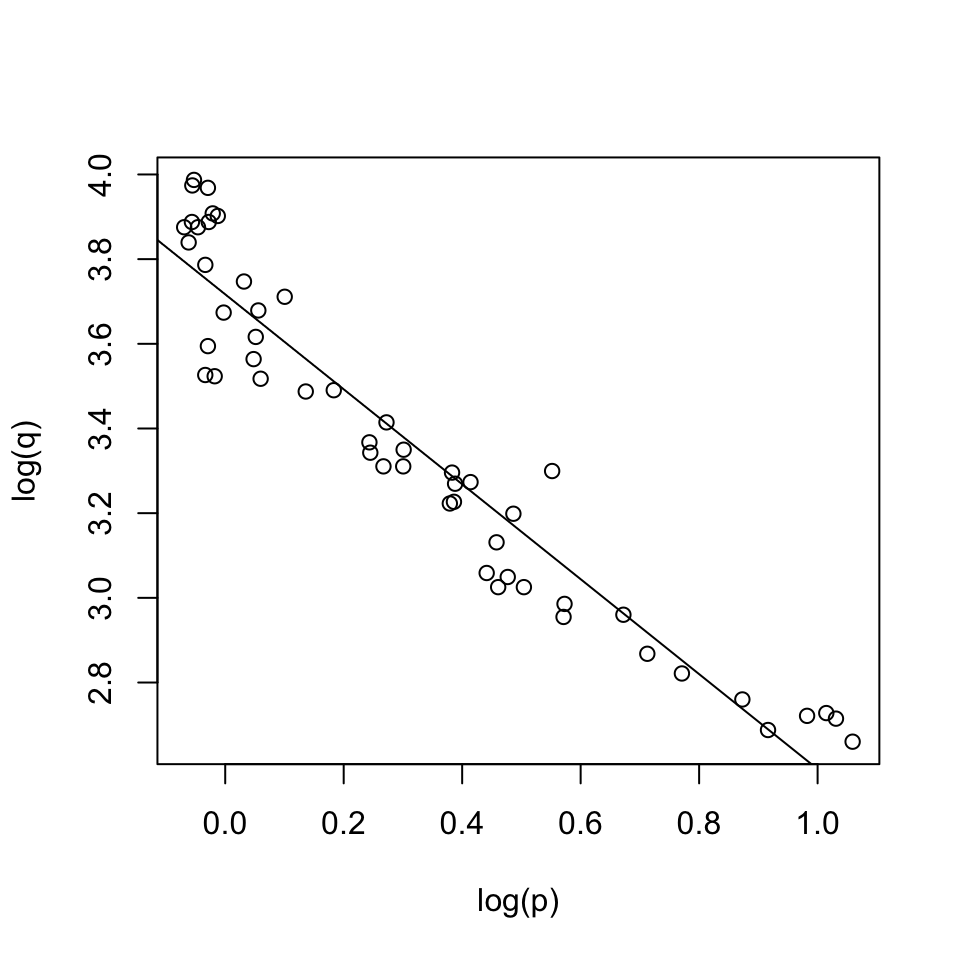

```r
# mod.a é inadequado
mod6 <- lm(log(q)~log(p), data=newbroiler)
plot(mod6$model[,2:1]); abline(mod6)
```

```r
mod6$residuals %>% scale %>% shapiro.test()
```

```
##
##  Shapiro-Wilk normality test
##
## data:  .
## W = 0.97287, p-value = 0.2787
```

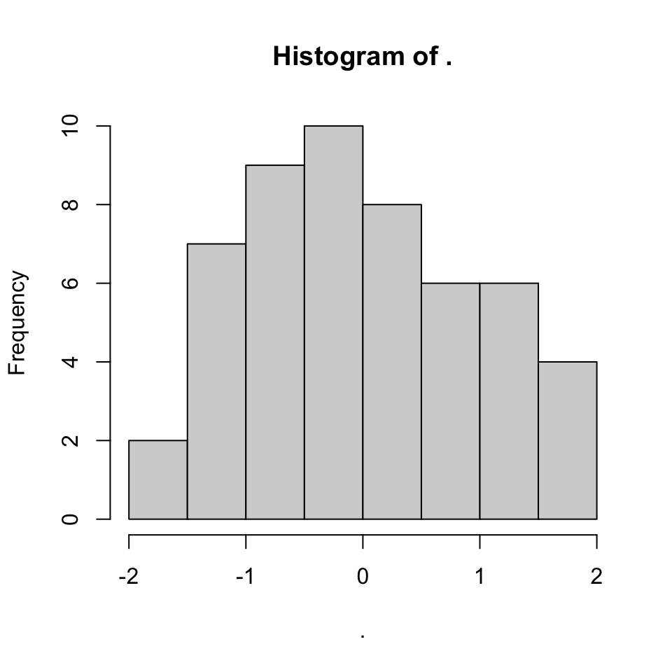

```r
mod6$residuals %>% scale %>% hist
```

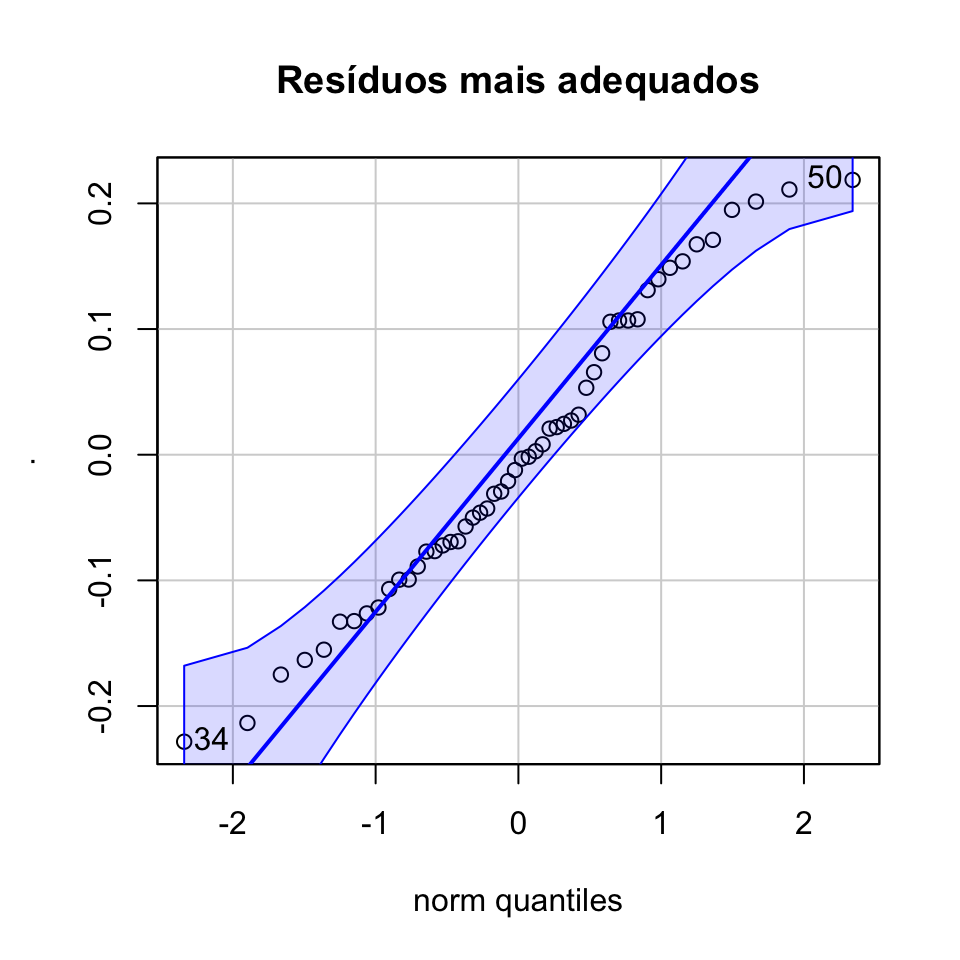

```
## [1] 34 50
```

```r
mod6$residuals %>% qqPlot(main="Resíduos mais adequados")
```

```r
mod6 %>% reset
```

```
##
##  RESET test
##
## data:  .
## RESET = 9.0626, df1 = 2, df2 = 48, p-value = 0.0004581
```

```r
nrow(newbroiler)
```

```
## [1] 52
```

```r
mod6 %>% bptest
```

```
##
##  studentized Breusch-Pagan test
##
## data:  .
## BP = 2.5034, df = 1, p-value = 0.1136
```

```r
mod6.a <- lm(log(q)~I(log(p)^3), data=newbroiler)
mod6.a$residuals %>% scale %>% shapiro.test()
```

```
##
##  Shapiro-Wilk normality test
##
## data:  .
## W = 0.94107, p-value = 0.01238
```

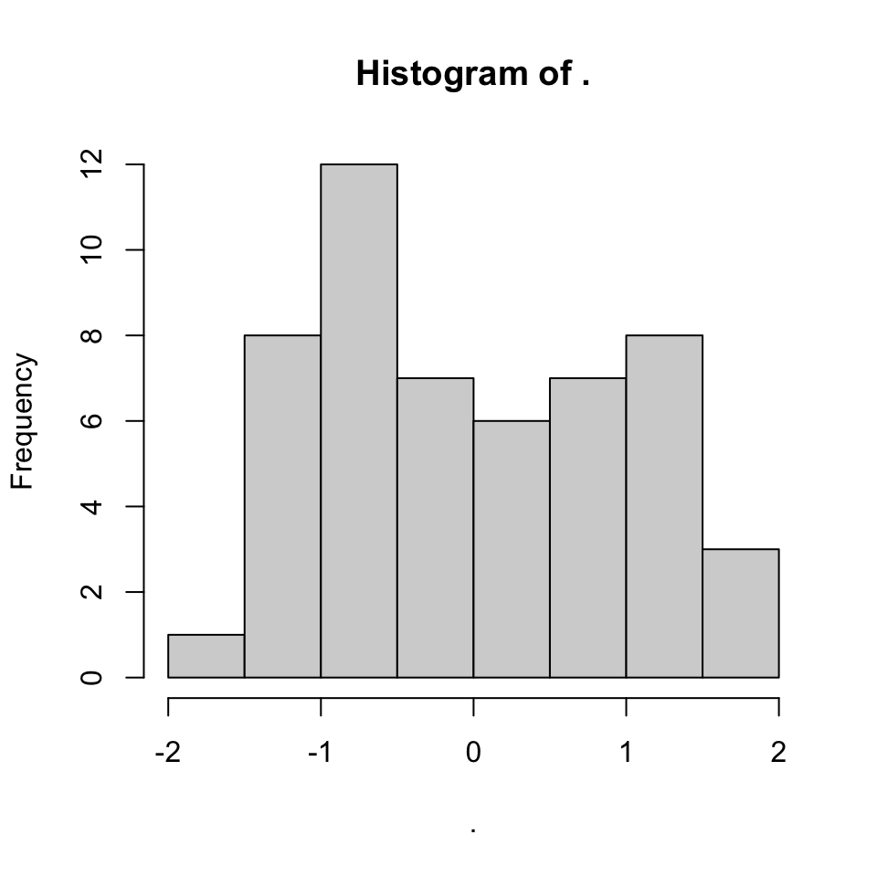

```r
mod6.a$residuals %>% scale %>% hist
```

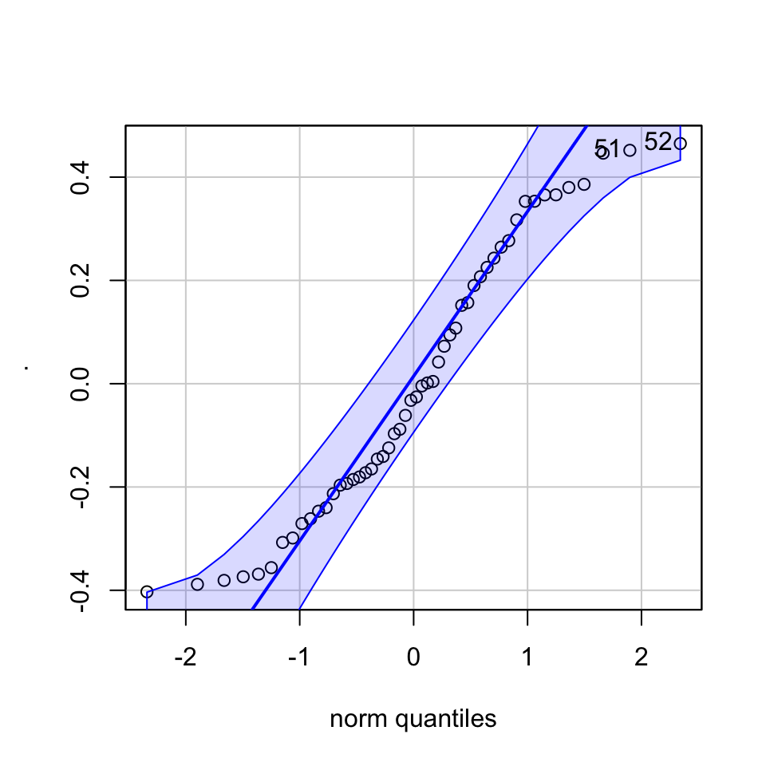

```
## [1] 52 51
```

```r
mod6.a$residuals %>% qqPlot()
```

```r
mod6.a %>% reset
```

```
##
##  RESET test
##
## data:  .
## RESET = 32.957, df1 = 2, df2 = 48, p-value = 9.816e-10
```

```r
mod.a.a <- lm(q~p+I(p^2)+I(p^3), newbroiler)
# aproximação de terceiro grau
mod.a.a$residuals %>% scale %>% shapiro.test()
```

```
##
##  Shapiro-Wilk normality test
##
## data:  .
## W = 0.94371, p-value = 0.01589
```

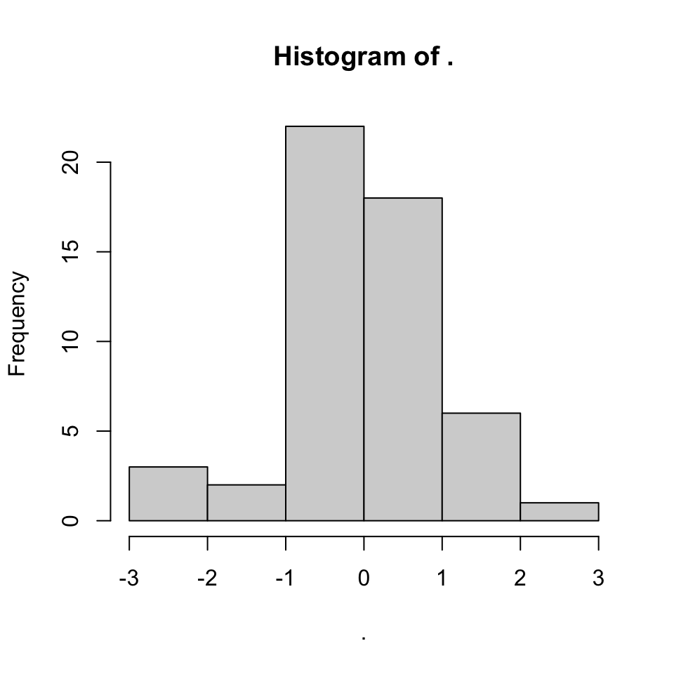

```r
mod.a.a$residuals %>% scale %>% hist
```

```r
mod.a.a %>% reset
```

```
##
##  RESET test
##
## data:  .
## RESET = 2.6918, df1 = 2, df2 = 46, p-value = 0.07843
```

````
```
````

````
```{r,}
````

```r
summary(mod6)
```

```
##
## Call:
## lm(formula = log(q) ~ log(p), data = newbroiler)
##
## Residuals:
##       Min        1Q    Median        3Q       Max
## -0.228363 -0.080077 -0.007662  0.106041  0.218679
##
## Coefficients:
##             Estimate Std. Error t value Pr(>|t|)
## (Intercept)  3.71694    0.02236   166.2   <2e-16 ***
## log(p)      -1.12136    0.04876   -23.0   <2e-16 ***
## ---
## Signif. codes:  0 '***' 0.001 '**' 0.01 '*' 0.05 '.' 0.1 ' ' 1
##
## Residual standard error: 0.118 on 50 degrees of freedom
## Multiple R-squared:  0.9136, Adjusted R-squared:  0.9119
## F-statistic:   529 on 1 and 50 DF,  p-value: < 2.2e-16
```

```r
# R^2 generalizado
cor(mod6$fitted.values, log(newbroiler$q))^2
```

```
## [1] 0.9136386
```

````
```
````

````
```{r,}
````

```r
modelo.linear.newbroiler = lm(q~p, data=newbroiler)
modelo.quadratico.newbroiler = lm(q~I(p^2), data=newbroiler)
modelo.quadratico.newbroiler %>% summary
```

```
##
## Call:
## lm(formula = q ~ I(p^2), data = newbroiler)
##
## Residuals:
##     Min      1Q  Median      3Q     Max
## -10.128  -5.888  -3.190   6.574  15.670
##
## Coefficients:
##             Estimate Std. Error t value Pr(>|t|)
## (Intercept)   42.415      1.702  24.915  < 2e-16 ***
## I(p^2)        -4.650      0.549  -8.471 3.14e-11 ***
## ---
## Signif. codes:  0 '***' 0.001 '**' 0.01 '*' 0.05 '.' 0.1 ' ' 1
##
## Residual standard error: 7.757 on 50 degrees of freedom
## Multiple R-squared:  0.5893, Adjusted R-squared:  0.5811
## F-statistic: 71.75 on 1 and 50 DF,  p-value: 3.138e-11
```

````
```
````

## 9.8 Overfitting

Sobreajustamento ou *overfitting* é o fenômeno em que o modelo tem uma complexidade excessiva para explicar o fenômeno, fazendo excelentes previsões para os pontos conhecidos da amostra, mas não conseguindo lidar bem com pontos desconhecidos.

No exemplo a seguir, temos um conjunto de pontos que pode ser adequadamente aproximado por uma reta mas que foi sobreajustado por um polinômio de quarto grau e outro de nono grau.

````
```{r,fig.asp=1, fig.width=5}
````

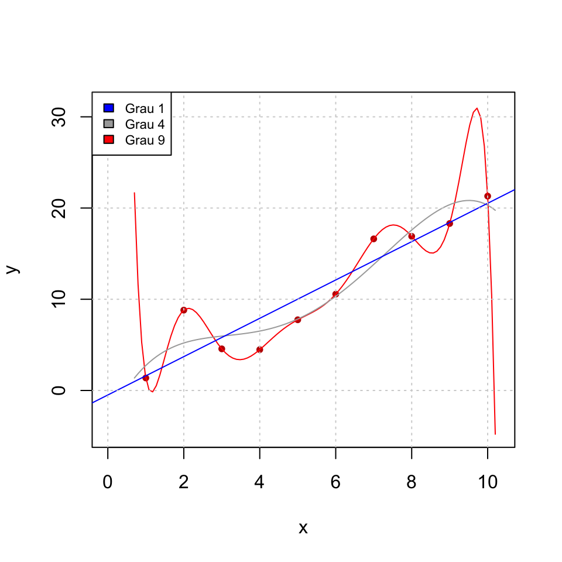

````
```
````

```r
# semente aleatória
set.seed(112)
# 10 valores de x
x = 1:10
# 10 valores de y
y = 2*x+2*rnorm(x)
# regressão por um polinômio de grau 9
lm(y~x+I(x^2)+I(x^3)+I(x^4)+I(x^5)+I(x^6)+I(x^7)+I(x^8)+I(x^9)) -> m9
# regressão por um polinômio de grau 4
lm(y~x+I(x^2)+I(x^3)+I(x^4)) -> m4
# regressão linear
lm(y~x) -> m1
# calcula a curva polinomial
xx = seq(-0.3+min(x), max(x)+0.2, length.out = 100)
yy = predict(m9, data.frame(x = xx))
yy4 = predict(m4, data.frame(x = xx))
# plota os pontos respeitando os máximos e mínimos da curva polinomial
plot(x, y, ylim = c(min(c(0, y, yy, yy4)), max(c(y, yy, yy4))*1.01), xlim = c(min(c(0, x, xx)), max(c(x, xx))*1.01), xlab = expression(x), ylab = expression(y), pch = 20, col = "#C00000")
# desenha a curva polinomial
lines(xx, yy, col = "red")
lines(xx, yy4, col = "darkgray")
# resenha uma simples reta de regressão
abline(m1, col = "blue")
grid()
legend("topleft", legend = paste("Grau", c(1, 4, 9)), fill = c("blue", "darkgray", "red"), cex = 0.7)
```

Percebe-se que no polinômio de grau 9 o ajuste ficará muito ruim para pontos fora da amostra, em especial aqueles que ultrapassarem os limites desta.

# AULA 4

````
```{r,}
````

```r
library(magrittr)
```

# 10 Chapter 5 The Multiple Regression Model

## 10.1 5.1 The General Model

Supondo que nossa amostra possui $m$ variáveis explicativas e $n$ casos observados

$$\widehat{y} = b_0 + b_1x_1 + b_2x_2+\cdots+b_mx_m$$

## 10.2 5.2 Example: Big Andy’s Hamburger Sales

$$sales=\beta_0+\beta_1price+\beta_2advert+e$$

$H_1: \beta_1$ deve ser negativo

$H_2: \beta_2$ deve ser positivo

Freund, J. E., & Simon, G. A. 2000. Estatística aplicada: Economia, administração e contabilidade (9th ed.). Porto Alegre: Bookman.

minhabiblioteca.ufpr.br

````
```{r,}
````

```r
library(PoEdata)
data(andy)
head(andy)
```

| sales | price | advert |
| --- | --- | --- |
| 73.2 | 5.69 | 1.3 |
| 71.8 | 6.49 | 2.9 |
| 62.4 | 5.63 | 0.8 |
| 67.4 | 6.22 | 0.7 |
| 89.3 | 5.02 | 1.5 |
| 70.3 | 6.41 | 1.3 |

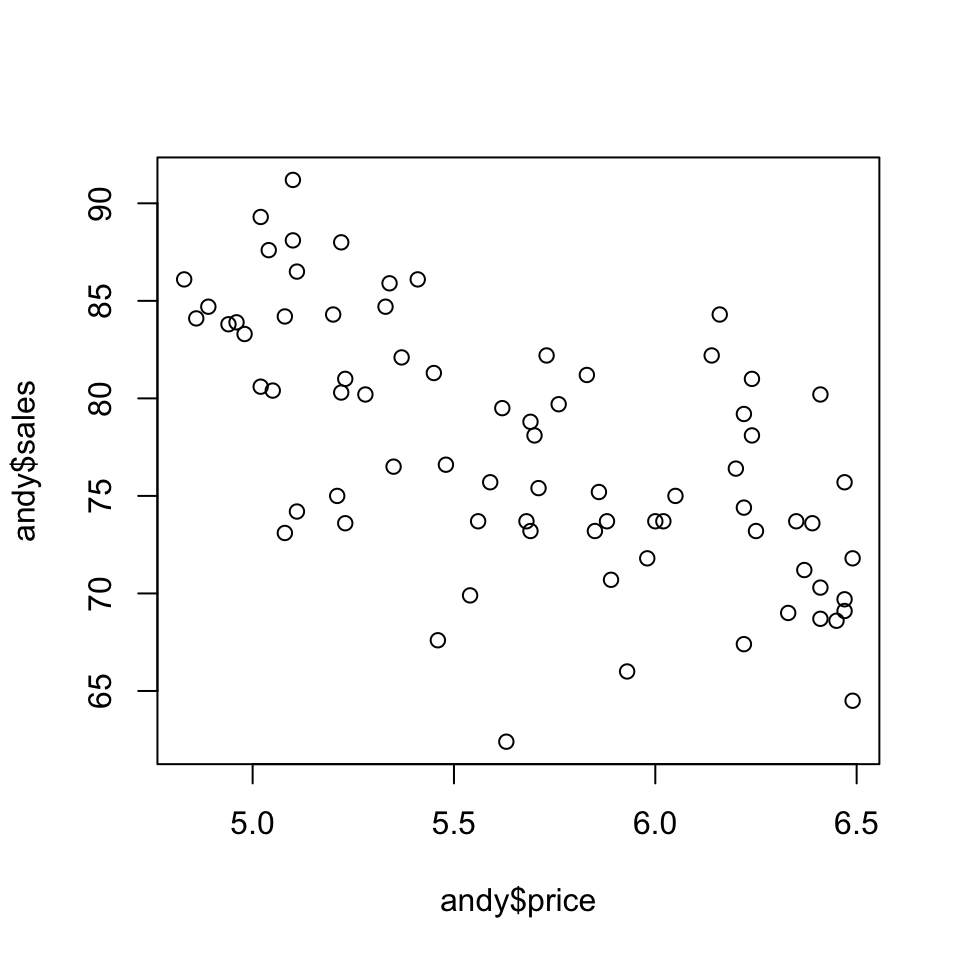

```r
plot(andy$price, andy$sales)
```

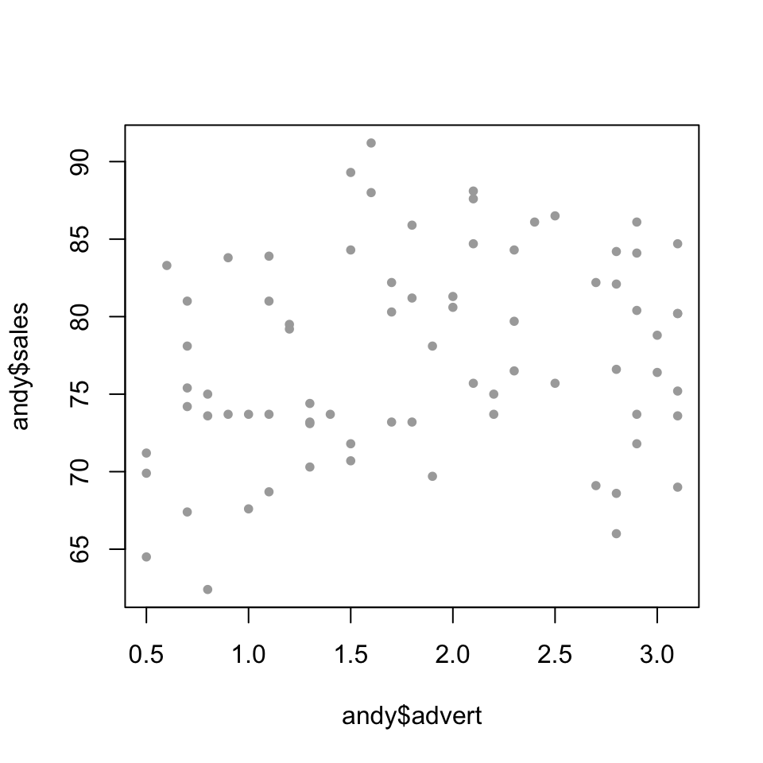

````
```
````

````
```{r,}
````

```r
plot(andy$advert, andy$sales, ylim = c(min(andy$sales), max(andy$sales)), pch = 20, col = "darkgray")
```

```r
library(xtable)
mod1 <- lm(sales~price+advert, data=andy)
library(knitr)
kable(summary(mod1) %>% xtable %>% data.frame)
```

|  | Estimate | Std..Error | t.value | Pr…t.. |
| --- | --- | --- | --- | --- |
| (Intercept) | 118.913610 | 6.3516375 | 18.721725 | 0.0000000 |
| price | -7.907854 | 1.0959930 | -7.215242 | 0.0000000 |
| advert | 1.862584 | 0.6831955 | 2.726283 | 0.0080382 |

```r
summary(mod1)
```

```
##
## Call:
## lm(formula = sales ~ price + advert, data = andy)
##
## Residuals:
##      Min       1Q   Median       3Q      Max
## -13.4825  -3.1434  -0.3456   2.8754  11.3049
##
## Coefficients:
##             Estimate Std. Error t value Pr(>|t|)
## (Intercept) 118.9136     6.3516  18.722  < 2e-16 ***
## price        -7.9079     1.0960  -7.215 4.42e-10 ***
## advert        1.8626     0.6832   2.726  0.00804 **
## ---
## Signif. codes:  0 '***' 0.001 '**' 0.01 '*' 0.05 '.' 0.1 ' ' 1
##
## Residual standard error: 4.886 on 72 degrees of freedom
## Multiple R-squared:  0.4483, Adjusted R-squared:  0.4329
## F-statistic: 29.25 on 2 and 72 DF,  p-value: 5.041e-10
```

````
```
````

````
```{r,}
````

```r
library(lmtest)
# Teste 1: normalidade dos resíduos
# estará tudo OK se eu não rejeitar a H0 de normalidade
shapiro.test(mod1$residuals)
```

```
##
##  Shapiro-Wilk normality test
##
## data:  mod1$residuals
## W = 0.98797, p-value = 0.7028
```

```r
# Teste 2: forma funcional (teste RESET de Ramsey)
# se aceitar H0 a forma funcional é adequada
reset(mod1)
```

```
##
##  RESET test
##
## data:  mod1
## RESET = 0.53369, df1 = 2, df2 = 70, p-value = 0.5888
```

```r
# Teste 3: heteroscedasticidade
# se não rejeitar H0 os resultados são homoscedásticos
bptest(mod1)
```

```
##
##  studentized Breusch-Pagan test
##
## data:  mod1
## BP = 2.5722, df = 2, p-value = 0.2763
```

````
```
````

````
```{r,}
````

```r
library(effects)
```

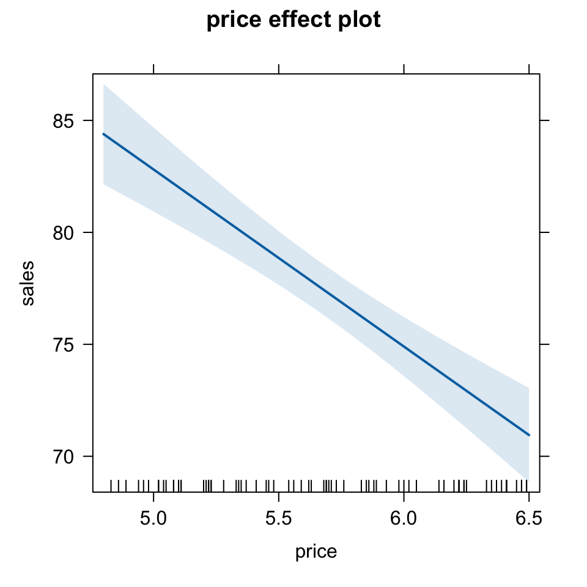

````
```
````

````
```{r,}
````

```r
effprice <- effect("price", mod1)
plot(effprice)
```

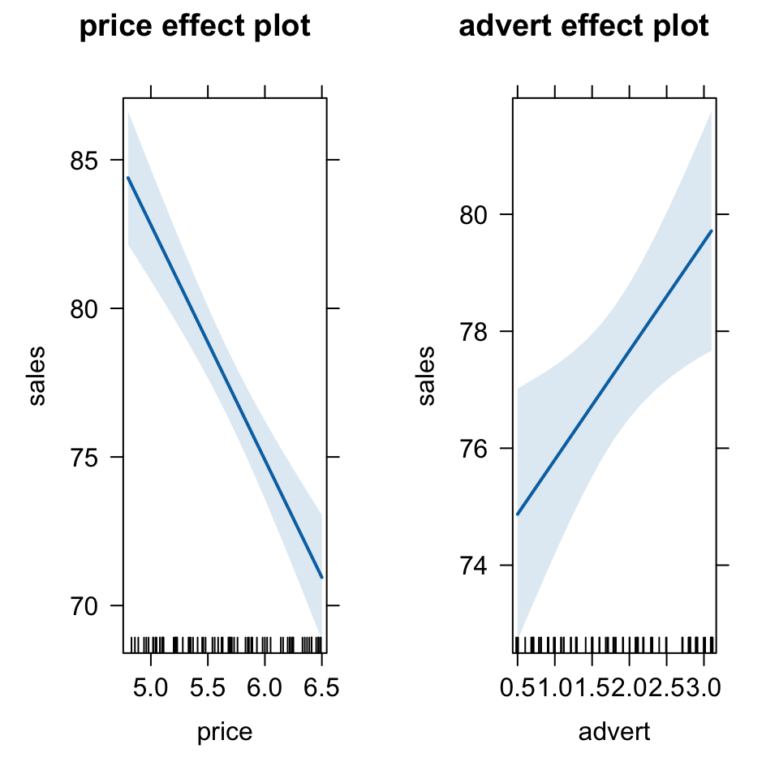

````
```
````

````
```{r,}
````

```r
alleffandy <- allEffects(mod1)
plot(alleffandy)
```

```r
mod2 <- lm(sales~price+advert+I(advert^2), data=andy)
summary(mod2)
```

```
##
## Call:
## lm(formula = sales ~ price + advert + I(advert^2), data = andy)
##
## Residuals:
##      Min       1Q   Median       3Q      Max
## -12.2553  -3.1430  -0.0117   2.8513  11.8050
##
## Coefficients:
##             Estimate Std. Error t value Pr(>|t|)
## (Intercept) 109.7190     6.7990  16.137  < 2e-16 ***
## price        -7.6400     1.0459  -7.304 3.24e-10 ***
## advert       12.1512     3.5562   3.417  0.00105 **
## I(advert^2)  -2.7680     0.9406  -2.943  0.00439 **
## ---
## Signif. codes:  0 '***' 0.001 '**' 0.01 '*' 0.05 '.' 0.1 ' ' 1
##
## Residual standard error: 4.645 on 71 degrees of freedom
## Multiple R-squared:  0.5082, Adjusted R-squared:  0.4875
## F-statistic: 24.46 on 3 and 71 DF,  p-value: 5.6e-11
```

````
```
````

````
```{r,}
````

```r
library(lmtest)
# Teste 1: normalidade dos resíduos
# estará tudo OK se eu não rejeitar a H0 de normalidade
shapiro.test(mod2$residuals)
```

```
##
##  Shapiro-Wilk normality test
##
## data:  mod2$residuals
## W = 0.98775, p-value = 0.6894
```

```r
# Teste 2: forma funcional (teste RESET de Ramsey)
# se aceitar H0 a forma funcional é adequada
reset(mod2)
```

```
##
##  RESET test
##
## data:  mod2
## RESET = 2.7695, df1 = 2, df2 = 69, p-value = 0.06967
```

```r
# Teste 3: heteroscedasticidade
# se não rejeitar H0 os resultados são homoscedásticos
bptest(mod1)
```

```
##
##  studentized Breusch-Pagan test
##
## data:  mod1
## BP = 2.5722, df = 2, p-value = 0.2763
```

````
```
````

````
```{r,}
````

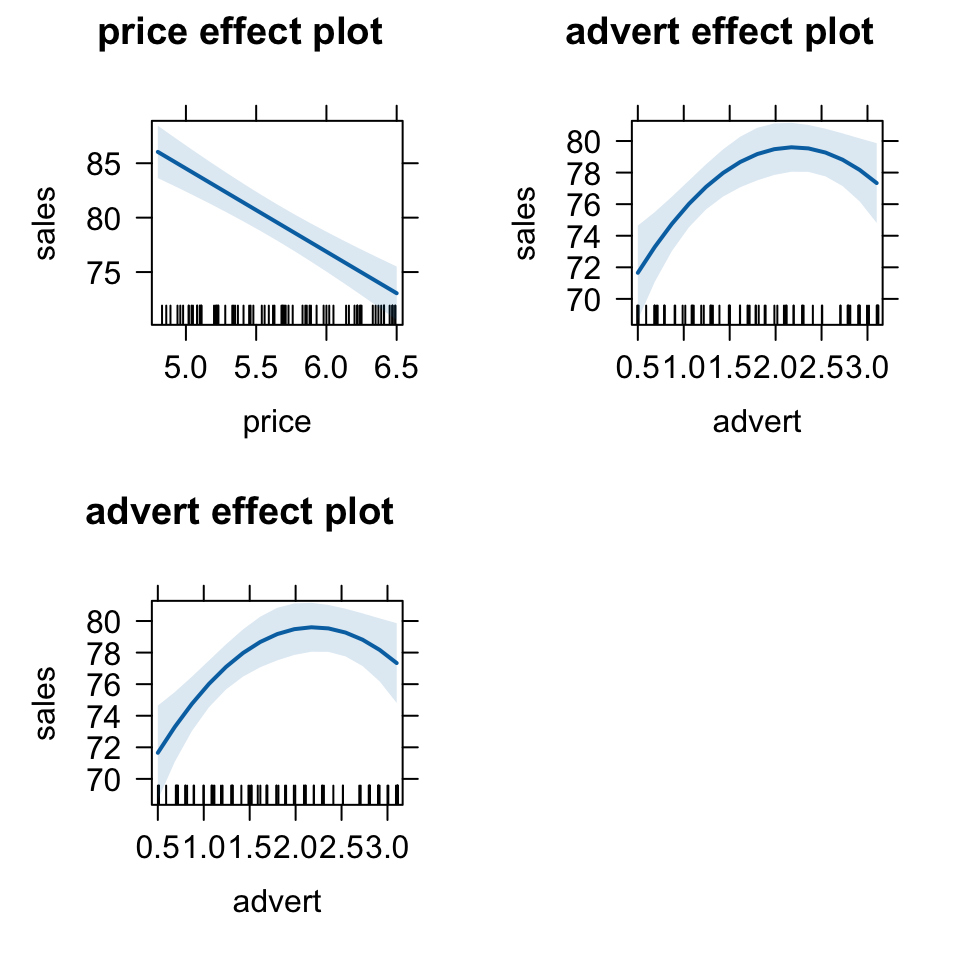

````
```
````

````
```{r,andyadvertxsales}
````

```r
alleffandy <- allEffects(mod2)
plot(alleffandy)
```

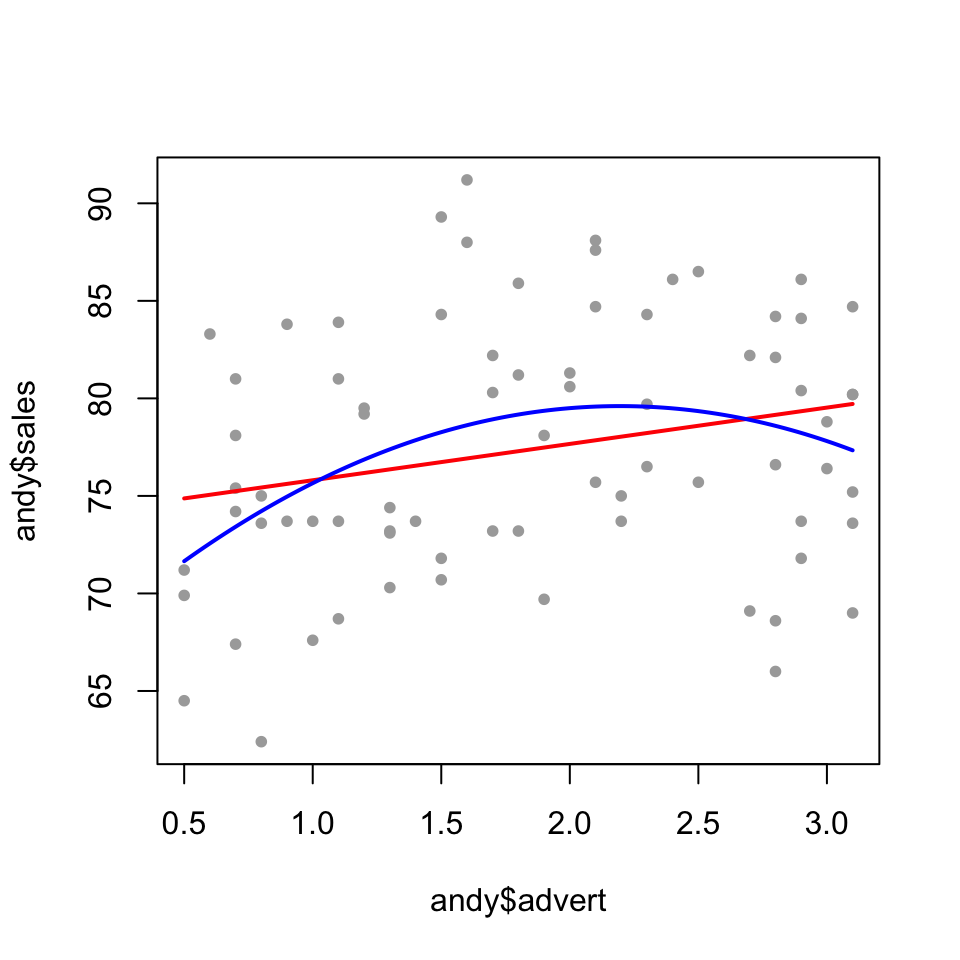

````
```
````

````
```{r,}
````

```r
plot(andy$advert, andy$sales, ylim = c(min(andy$sales), max(andy$sales)), pch = 20, col = "darkgray")
adv = seq(min(andy$advert), max(andy$advert), length.out = 100)
y = predict(mod1, data.frame(advert = adv, price = mean(andy$price)))
lines(adv, y, col = "red", lwd = 2)
y = predict(mod2, data.frame(advert = adv, price = mean(andy$price)))
lines(adv, y, col = "blue", lwd = 2)
```

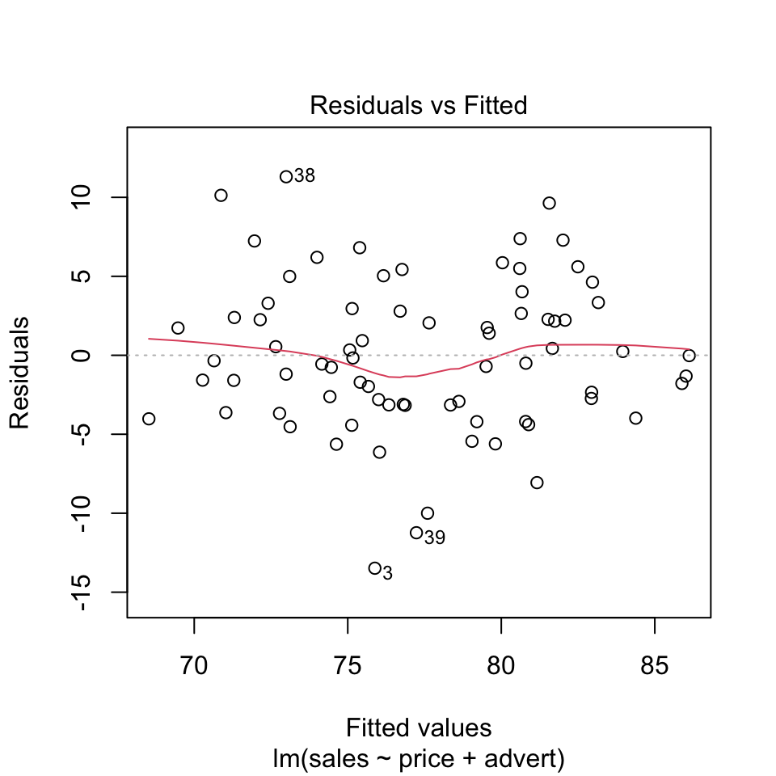

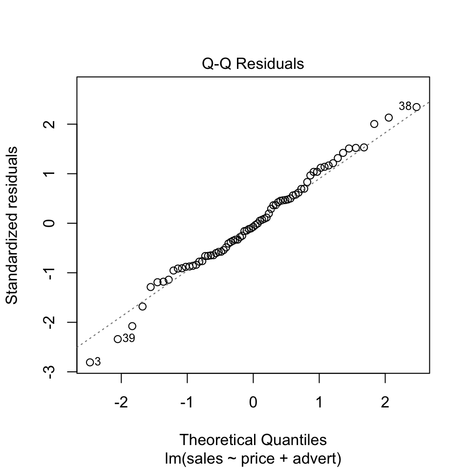

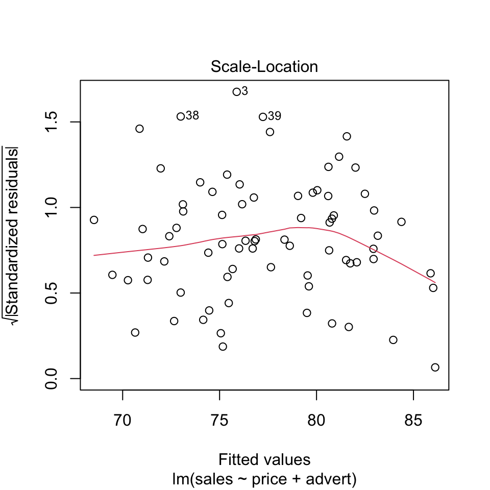

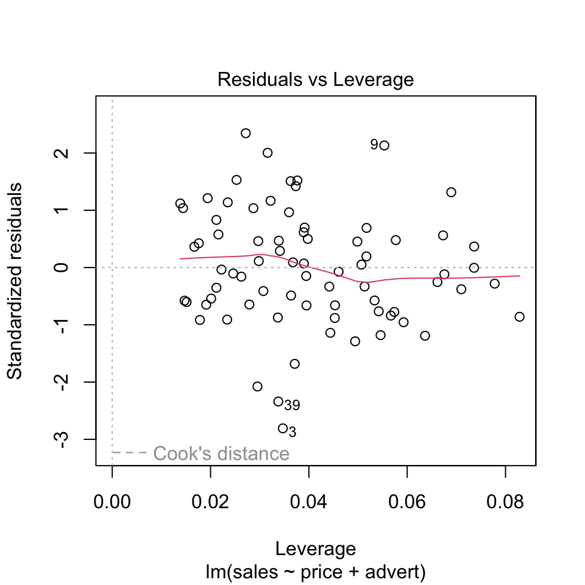

````
```
````

````
```{r,}
````

```r
plot(mod1)
```

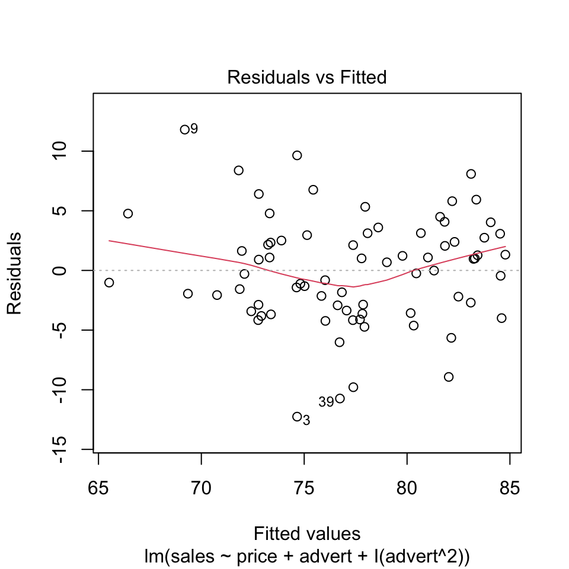

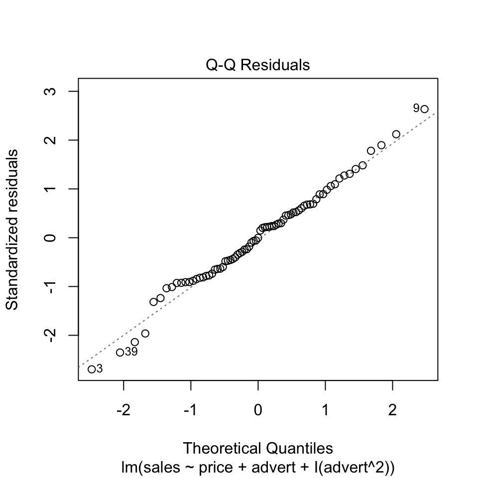

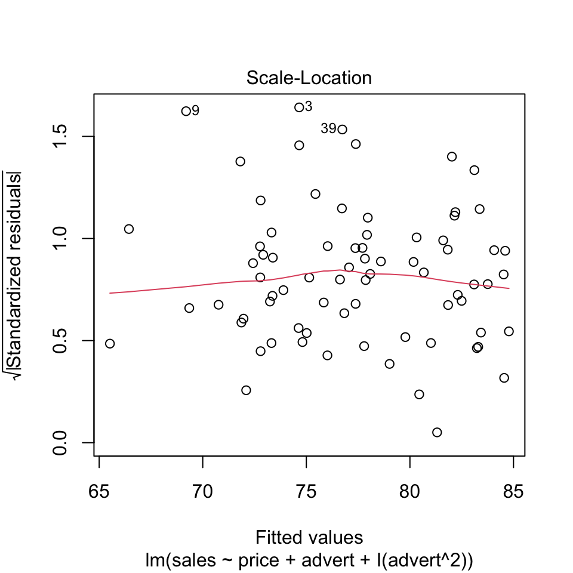

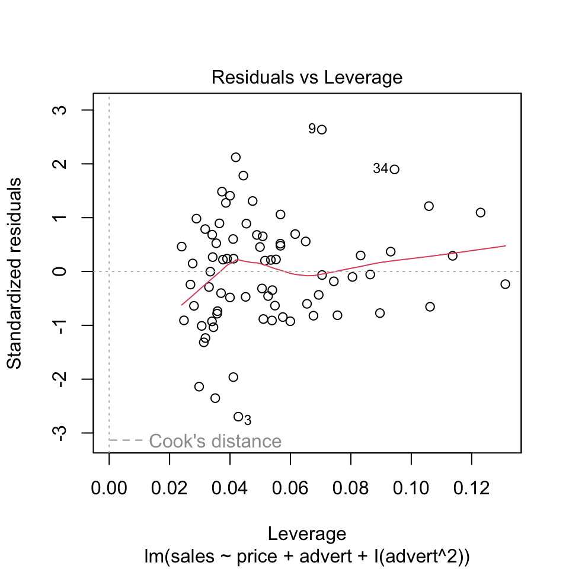

````
```
````

```r
plot(mod2)
```

Matrizes de covariância

````
```{r,}
````

```r
vcov(mod1)
```

|  | (Intercept) | price | advert |
| --- | --- | --- | --- |
| (Intercept) | 40.3432990 | -6.7950641 | -0.7484206 |
| price | -6.7950641 | 1.2012007 | -0.0197422 |
| advert | -0.7484206 | -0.0197422 | 0.4667561 |

```r
vcov(mod2)
```

|  | (Intercept) | price | advert | I(advert^2) |
| --- | --- | --- | --- | --- |
| (Intercept) | 46.227019 | -6.4261130 | -11.6009601 | 2.9390263 |
| price | -6.426113 | 1.0939881 | 0.3004062 | -0.0856191 |
| advert | -11.600960 | 0.3004062 | 12.6463020 | -3.2887457 |
| I(advert^2) | 2.939026 | -0.0856191 | -3.2887457 | 0.8847736 |

```r
cbind(andy$sales, andy$price, andy$advert, andy$advert^2) %>% var
```

| 42.101106 | -2.1042341 | 1.1984270 | 3.3387205 |
| --- | --- | --- | --- |
| -2.104234 | 0.2687718 | 0.0113681 | 0.0682647 |
| 1.198427 | 0.0113681 | 0.6916865 | 2.5721319 |
| 3.338720 | 0.0682647 | 2.5721319 | 9.8969231 |

````
```
````

Conseguimos comprovar as nossas hipóteses?

Conseguimos controlar as hipóteses alternativas?

$R^2_{aj}(mod1)=0.4329316$ e $R^2_{aj}(mod2)=0.4874564$

````
```{r,}
````

````
```
````

## 10.3 Distribuição t ou distribuição normal?

````
```{r,}
````

```r
qnorm(1-0.05/2) %>% round(4)
```

```
## [1] 1.96
```

```r
qt(1-0.05/2, 5000-2)
```

```
## [1] 1.960439
```

```r
qt(1-0.05/2, 500-2)
```

```
## [1] 1.964739
```

```r
qt(1-0.05/2, 200-2)
```

```
## [1] 1.972017
```

```r
qt(1-0.05/2, 120-2)
```

```
## [1] 1.980272
```

```r
qt(1-0.05/2, 30-2)
```

```
## [1] 2.048407
```

````
```
````

## 10.4 modelo polinomial do segundo grau para Andy

````
```{r,}
````

```r
mod2
```

```
##
## Call:
## lm(formula = sales ~ price + advert + I(advert^2), data = andy)
##
## Coefficients:
## (Intercept)        price       advert  I(advert^2)
##     109.719       -7.640       12.151       -2.768
```

````
```
````

Qual o valor máximo a ser investido em propaganda?

Fica perto do ponto onde a parábola atinge o seu máximo.

Ponto de máximo:

$$advert = \dfrac{-b}{2a} = \dfrac{-12.151}{2(-2.768)} = \dfrac{12.151}{5.536} \approx 2.194906$$

````
```{r,}
````

```r
12.151/(2*2.768)
```

```
## [1] 2.194906
```

````
```
````

````
```{r,}
````

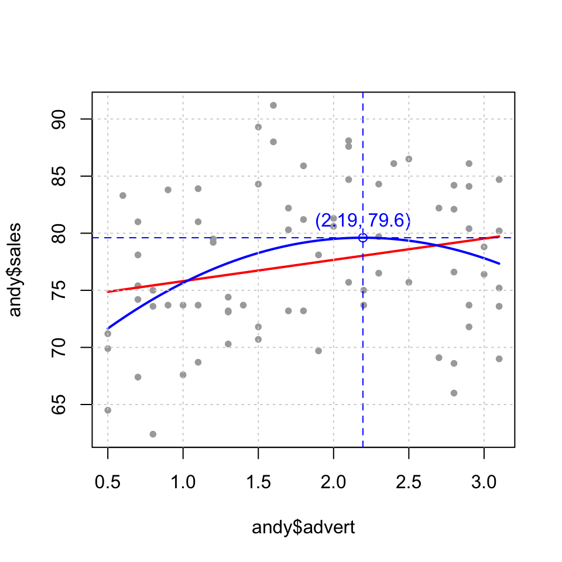

```r
plot(andy$advert, andy$sales, ylim = c(min(andy$sales), max(andy$sales)), pch = 20, col = "darkgray")
adv = seq(min(andy$advert), max(andy$advert), length.out = 100)
y = predict(mod1, data.frame(advert = adv, price = mean(andy$price)))
lines(adv, y, col = "red", lwd = 2)
y = predict(mod2, data.frame(advert = adv, price = mean(andy$price)))
lines(adv, y, col = "blue", lwd = 2)
xmax = 12.151/(2*2.768)
ymax = predict(mod2, data.frame(price = mean(andy$price), advert = xmax))
abline(v = xmax, h = ymax, lty = 2, col = "blue")
points(xmax, ymax, col = "blue")
text(xmax, ymax, paste("(", xmax %>% round(2), ", ", ymax %>% round(2), ")", sep = ""), pos = 3, col = "blue")
grid()
```

```r
mean(andy$price)
```

```
## [1] 5.6872
```

````
```
````

## 10.5 5.6 Interaction Terms in Linear Regression

````
```{r,}
````

```r
data("pizza4",package="PoEdata")
head(pizza4)
```

| pizza | female | hs | college | grad | income | age |
| --- | --- | --- | --- | --- | --- | --- |
| 109 | 1 | 0 | 0 | 0 | 19.5 | 25 |
| 0 | 1 | 0 | 0 | 0 | 39.0 | 45 |
| 0 | 1 | 0 | 0 | 0 | 15.6 | 20 |
| 108 | 1 | 0 | 0 | 0 | 26.0 | 28 |
| 220 | 1 | 1 | 0 | 0 | 19.5 | 25 |
| 189 | 1 | 1 | 0 | 0 | 39.0 | 35 |

```r
?pizza4
```

| pizza4 | R Documentation |
| --- | --- |

## Pizza4 Data

### Description

Obs: 40 individuals

### Usage

```r
data("pizza4")
```

### Format

A data frame with 40 observations on the following 7 variables.

**`pizza`**

annual pizza expenditure, $

**`female`**

=1 if female

**`hs`**

=1 if highest degree received is high school diploma

**`college`**

=1 if highest degree received is a college diploma

**`grad`**

=1 if highest degree received is a post graduate degree

**`income`**

annual income in thousands of dollars

**`age`**

age in years

### Source

http://principlesofeconometrics.com/poe4/poe4.htm

### Examples

```r
data(pizza4)
## maybe str(pizza4) ; plot(pizza4) ...
```

````
```
````

````
```{r,}
````

```r
mod3 = lm(pizza~income, data = pizza4)
mod3 %>% summary
```

```
##
## Call:
## lm(formula = pizza ~ income, data = pizza4)
##
## Residuals:
##     Min      1Q  Median      3Q     Max
## -260.17 -103.81  -49.86  122.59  337.12
##
## Coefficients:
##             Estimate Std. Error t value Pr(>|t|)
## (Intercept) 128.9803    34.5913   3.729 0.000626 ***
## income        1.1213     0.4595   2.440 0.019461 *
## ---
## Signif. codes:  0 '***' 0.001 '**' 0.01 '*' 0.05 '.' 0.1 ' ' 1
##
## Residual standard error: 146.8 on 38 degrees of freedom
## Multiple R-squared:  0.1355, Adjusted R-squared:  0.1127
## F-statistic: 5.954 on 1 and 38 DF,  p-value: 0.01946
```

```r
mod3 = lm(pizza~age, data = pizza4)
mod3 %>% summary
```

```
##
## Call:
## lm(formula = pizza ~ age, data = pizza4)
##
## Residuals:
##     Min      1Q  Median      3Q     Max
## -235.90 -131.28  -18.39  107.80  393.60
##
## Coefficients:
##             Estimate Std. Error t value Pr(>|t|)
## (Intercept)  301.728     84.206   3.583 0.000951 ***
## age           -3.291      2.408  -1.367 0.179671
## ---
## Signif. codes:  0 '***' 0.001 '**' 0.01 '*' 0.05 '.' 0.1 ' ' 1
##
## Residual standard error: 154.2 on 38 degrees of freedom
## Multiple R-squared:  0.04687,    Adjusted R-squared:  0.02179
## F-statistic: 1.869 on 1 and 38 DF,  p-value: 0.1797
```

```r
mod3 = lm(pizza~age+income, data = pizza4)
mod3 %>% summary
```

```
##
## Call:
## lm(formula = pizza ~ age + income, data = pizza4)
##
## Residuals:
##     Min      1Q  Median      3Q     Max
## -219.96 -116.36   27.85   88.02  287.04
##
## Coefficients:
##             Estimate Std. Error t value Pr(>|t|)
## (Intercept) 342.8848    72.3434   4.740 3.14e-05 ***
## age          -7.5756     2.3170  -3.270 0.002333 **
## income        1.8325     0.4643   3.947 0.000341 ***
## ---
## Signif. codes:  0 '***' 0.001 '**' 0.01 '*' 0.05 '.' 0.1 ' ' 1
##
## Residual standard error: 131.1 on 37 degrees of freedom
## Multiple R-squared:  0.3293, Adjusted R-squared:  0.293
## F-statistic: 9.081 on 2 and 37 DF,  p-value: 0.0006185
```

```r
mod3 = lm(pizza~age+income+age:income, data = pizza4)
mod3 %>% summary
```

```
##
## Call:
## lm(formula = pizza ~ age + income + age:income, data = pizza4)
##
## Residuals:
##     Min      1Q  Median      3Q     Max
## -200.86  -83.82   20.70   85.04  254.23
##
## Coefficients:
##              Estimate Std. Error t value Pr(>|t|)
## (Intercept) 161.46543  120.66341   1.338   0.1892
## age          -2.97742    3.35210  -0.888   0.3803
## income        6.97991    2.82277   2.473   0.0183 *
## age:income   -0.12324    0.06672  -1.847   0.0730 .
## ---
## Signif. codes:  0 '***' 0.001 '**' 0.01 '*' 0.05 '.' 0.1 ' ' 1
##
## Residual standard error: 127 on 36 degrees of freedom
## Multiple R-squared:  0.3873, Adjusted R-squared:  0.3363
## F-statistic: 7.586 on 3 and 36 DF,  p-value: 0.0004681
```

```r
mod3 = lm(pizza~age+income+income:age, data = pizza4)
mod3 %>% summary
```

```
##
## Call:
## lm(formula = pizza ~ age + income + income:age, data = pizza4)
##
## Residuals:
##     Min      1Q  Median      3Q     Max
## -200.86  -83.82   20.70   85.04  254.23
##
## Coefficients:
##              Estimate Std. Error t value Pr(>|t|)
## (Intercept) 161.46543  120.66341   1.338   0.1892
## age          -2.97742    3.35210  -0.888   0.3803
## income        6.97991    2.82277   2.473   0.0183 *
## age:income   -0.12324    0.06672  -1.847   0.0730 .
## ---
## Signif. codes:  0 '***' 0.001 '**' 0.01 '*' 0.05 '.' 0.1 ' ' 1
##
## Residual standard error: 127 on 36 degrees of freedom
## Multiple R-squared:  0.3873, Adjusted R-squared:  0.3363
## F-statistic: 7.586 on 3 and 36 DF,  p-value: 0.0004681
```

```r
mod3 = lm(pizza~age*income, data = pizza4)
mod3 %>% summary
```

```
##
## Call:
## lm(formula = pizza ~ age * income, data = pizza4)
##
## Residuals:
##     Min      1Q  Median      3Q     Max
## -200.86  -83.82   20.70   85.04  254.23
##
## Coefficients:
##              Estimate Std. Error t value Pr(>|t|)
## (Intercept) 161.46543  120.66341   1.338   0.1892
## age          -2.97742    3.35210  -0.888   0.3803
## income        6.97991    2.82277   2.473   0.0183 *
## age:income   -0.12324    0.06672  -1.847   0.0730 .
## ---
## Signif. codes:  0 '***' 0.001 '**' 0.01 '*' 0.05 '.' 0.1 ' ' 1
##
## Residual standard error: 127 on 36 degrees of freedom
## Multiple R-squared:  0.3873, Adjusted R-squared:  0.3363
## F-statistic: 7.586 on 3 and 36 DF,  p-value: 0.0004681
```

````
```
````

````
```{r,}
````

```r
data(cps4_small)
head(cps4_small)
```

| wage | educ | exper | hrswk | married | female | metro | midwest | south | west | black | asian |
| --- | --- | --- | --- | --- | --- | --- | --- | --- | --- | --- | --- |
| 18.70 | 16 | 39 | 37 | 1 | 1 | 1 | 0 | 1 | 0 | 0 | 0 |
| 11.50 | 12 | 16 | 62 | 0 | 0 | 0 | 1 | 0 | 0 | 0 | 0 |
| 15.04 | 16 | 13 | 40 | 1 | 0 | 1 | 0 | 0 | 1 | 1 | 0 |
| 25.95 | 14 | 11 | 40 | 0 | 1 | 1 | 0 | 1 | 0 | 1 | 0 |
| 24.03 | 12 | 51 | 40 | 1 | 0 | 1 | 0 | 0 | 0 | 0 | 0 |
| 20.00 | 12 | 30 | 40 | 1 | 0 | 1 | 0 | 0 | 0 | 0 | 0 |

````
```
````

````
```{r,}
````

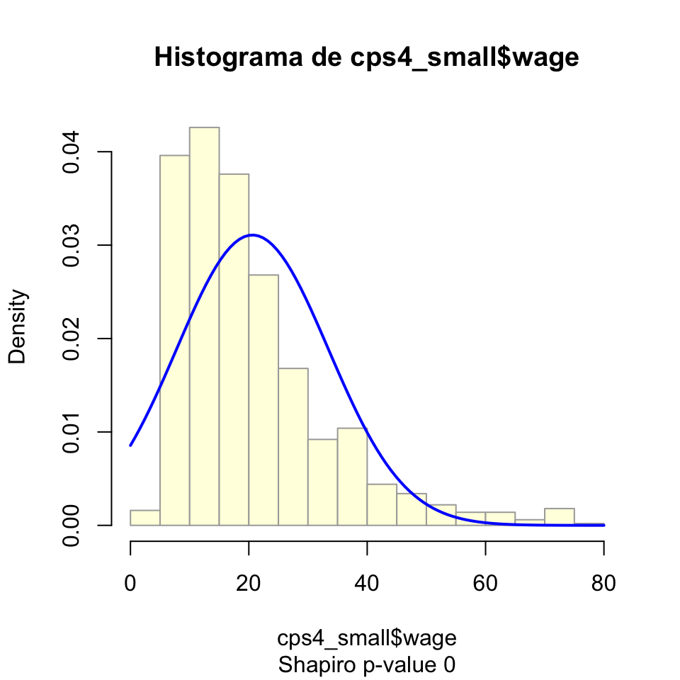

```r
# lembram da função mhist que foi definida no arquivo "Pequenos Experimentos.Rmd"?
# (dêem uma olhada lá)
# criei um arquivo que contém essa função (mhist.R) e para tornar essa funcionalidade
# disponível basta carregar o arquivo direto do github
source("https://raw.githubusercontent.com/jrfrega/2025/refs/heads/main/mhist.R")
# wage apresenta muitos outliers superiores
mhist(cps4_small$wage)
```

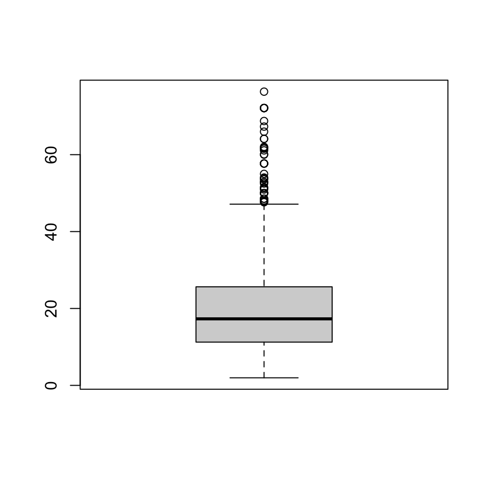

```r
boxplot(cps4_small$wage)
```

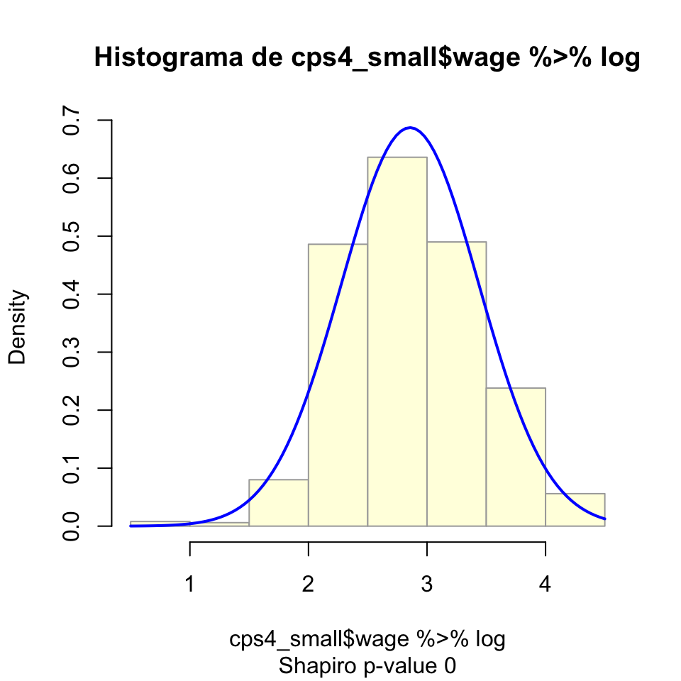

```r
# a transformação log reduz o problema a uns poucos outliers inferiores
mhist(cps4_small$wage %>% log)
```

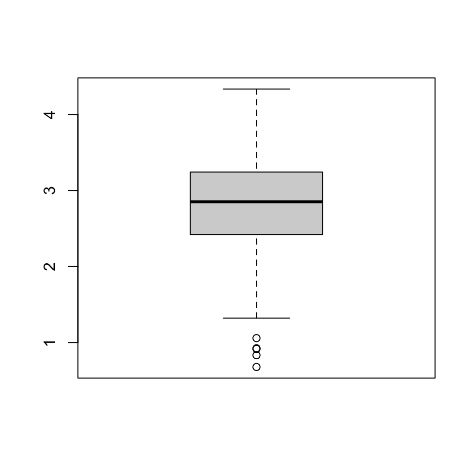

```r
boxplot(cps4_small$wage %>% log)
```

```r
# Lembrem de que qualquer modelo precisa ser suportado pela adequada teoria
# aqui está sendo proposta uma interação entre educ e exper
# e uma utilidade decrescente da exper
mod4 = lm(log(wage)~educ*exper+I(exper^2), data = cps4_small)
summary(mod4)
```

```
##
## Call:
## lm(formula = log(wage) ~ educ * exper + I(exper^2), data = cps4_small)
##
## Residuals:
##      Min       1Q   Median       3Q      Max
## -2.28227 -0.32856 -0.02725  0.33751  1.47088
##
## Coefficients:
##               Estimate Std. Error t value Pr(>|t|)
## (Intercept)  5.297e-01  2.267e-01   2.336  0.01969 *
## educ         1.272e-01  1.472e-02   8.642  < 2e-16 ***
## exper        6.298e-02  9.536e-03   6.604 6.48e-11 ***
## I(exper^2)  -7.139e-04  8.804e-05  -8.109 1.49e-15 ***
## educ:exper  -1.322e-03  4.949e-04  -2.672  0.00766 **
## ---
## Signif. codes:  0 '***' 0.001 '**' 0.01 '*' 0.05 '.' 0.1 ' ' 1
##
## Residual standard error: 0.5057 on 995 degrees of freedom
## Multiple R-squared:  0.2445, Adjusted R-squared:  0.2415
## F-statistic: 80.52 on 4 and 995 DF,  p-value: < 2.2e-16
```

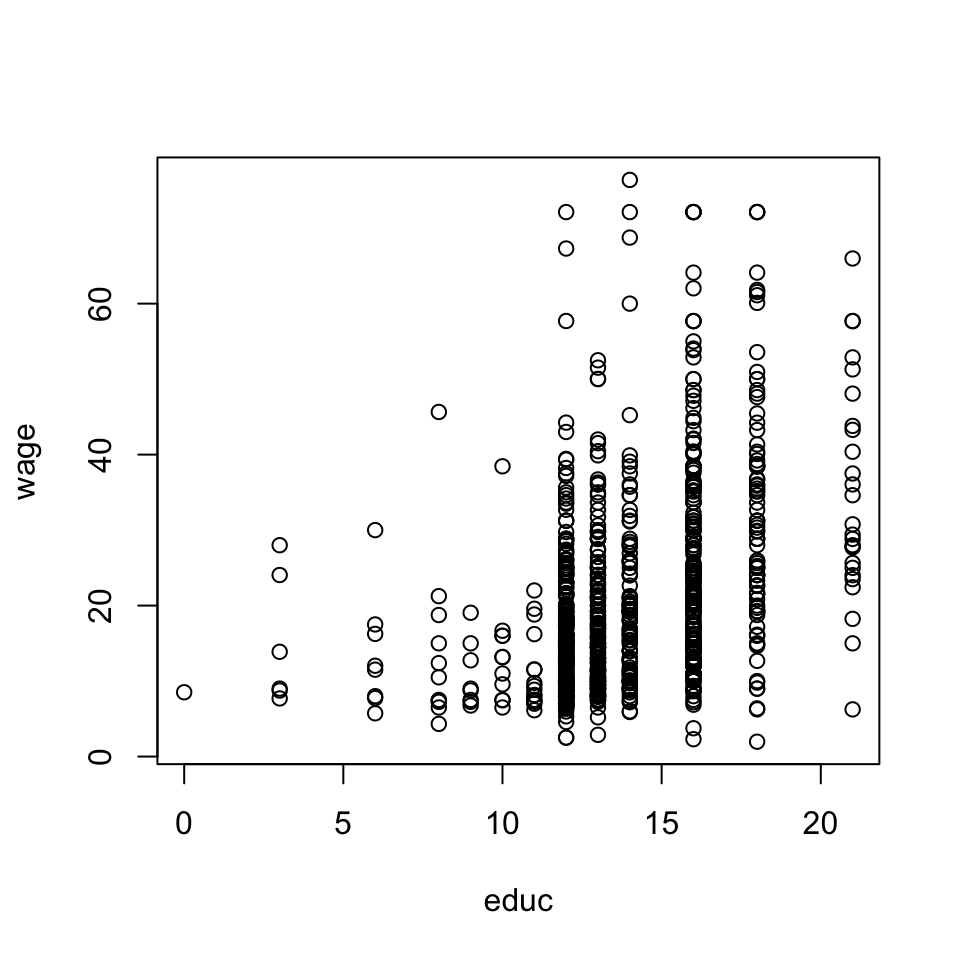

```r
with(cps4_small, plot(educ, wage))
```

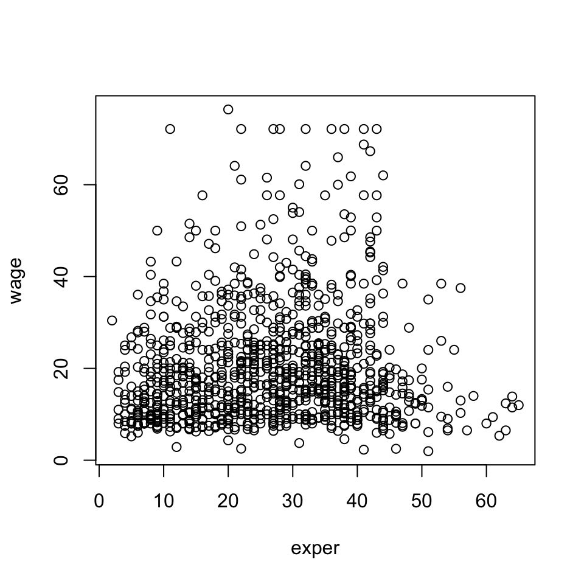

````
```
````

```r
with(cps4_small, plot(exper, wage))
```

# 11 Chapter 6 Further Inference in Multiple Regression

Necessidade de indicadores mais robustos que o $R^2$ para determinar a qualidade de uma regressão.

Modernamente, usa-se os critérios de informação

AIC (Akaike Information Criterion)

BIC (Bayesian Information Criterion)

````
```{r,}
````

```r
library(broom)
mod1
```

```
##
## Call:
## lm(formula = sales ~ price + advert, data = andy)
##
## Coefficients:
## (Intercept)        price       advert
##     118.914       -7.908        1.863
```

```r
mod2
```

```
##
## Call:
## lm(formula = sales ~ price + advert + I(advert^2), data = andy)
##
## Coefficients:
## (Intercept)        price       advert  I(advert^2)
##     109.719       -7.640       12.151       -2.768
```

```r
rbind(glance(mod1),
glance(mod2))
```

| r.squared | adj.r.squared | sigma | statistic | p.value | df | logLik | AIC | BIC | deviance | df.residual | nobs |
| --- | --- | --- | --- | --- | --- | --- | --- | --- | --- | --- | --- |
| 0.4482578 | 0.4329316 | 4.886124 | 29.24786 | 0 | 2 | -223.8695 | 455.739 | 465.0090 | 1718.943 | 72 | 75 |
| 0.5082352 | 0.4874564 | 4.645283 | 24.45932 | 0 | 3 | -219.5540 | 449.108 | 460.6954 | 1532.084 | 71 | 75 |

````
```
````

O melhor modelo é o que apresenta o menor valor para um dado critério de informação.

Com base no AIC, o modelo 1 (mod1) é pior que o modelo 2 (mod2) (455.739 > 449.108)

Os critérios de informação balanceiam a parcimônia do modelo com a qualidade do ajuste.

````
```{r,}
````

```r
mod1$call
```

```
## lm(formula = sales ~ price + advert, data = andy)
```

```r
mod2.1 = lm(formula = sales ~ price + advert + I(advert^2) + I(price^2), data = andy)
rbind(glance(mod1),
glance(mod2), glance(mod2.1))
```

| r.squared | adj.r.squared | sigma | statistic | p.value | df | logLik | AIC | BIC | deviance | df.residual | nobs |
| --- | --- | --- | --- | --- | --- | --- | --- | --- | --- | --- | --- |
| 0.4482578 | 0.4329316 | 4.886124 | 29.24786 | 0 | 2 | -223.8695 | 455.7390 | 465.0090 | 1718.943 | 72 | 75 |
| 0.5082352 | 0.4874564 | 4.645283 | 24.45932 | 0 | 3 | -219.5540 | 449.1080 | 460.6954 | 1532.084 | 71 | 75 |
| 0.5279827 | 0.5010102 | 4.583451 | 19.57491 | 0 | 4 | -218.0171 | 448.0341 | 461.9391 | 1470.561 | 70 | 75 |

```r
mod2.2 = lm(formula = sales ~ price + advert + I(advert^2) + I(advert^3) + I(price^2), data = andy)
rbind(glance(mod1),
glance(mod2), glance(mod2.1), glance(mod2.2)) %>% as.data.frame -> df
row.names(df) = c("mod1 (linear)", "mod2 (quadrático em advert)", "mod2.1 (quadrático em tudo)", "mod2.2 (quadrático em price, cúbico em advert")
df[, c("adj.r.squared", "AIC", "BIC")]
```

|  | adj.r.squared | AIC | BIC |
| --- | --- | --- | --- |
| mod1 (linear) | 0.4329316 | 455.7390 | 465.0090 |
| mod2 (quadrático em advert) | 0.4874564 | 449.1080 | 460.6954 |
| mod2.1 (quadrático em tudo) | 0.5010102 | 448.0341 | 461.9391 |
| mod2.2 (quadrático em price, cúbico em advert | 0.4938355 | 450.0257 | 466.2481 |

```r
summary(mod2.1)
```

```
##
## Call:
## lm(formula = sales ~ price + advert + I(advert^2) + I(price^2),
##     data = andy)
##
## Residuals:
##      Min       1Q   Median       3Q      Max
## -11.1771  -2.9378   0.0949   2.8897  11.6856
##
## Coefficients:
##             Estimate Std. Error t value Pr(>|t|)
## (Intercept) 248.8390    81.5712   3.051 0.003225 **
## price       -57.0629    28.8988  -1.975 0.052262 .
## advert       13.1624     3.5582   3.699 0.000427 ***
## I(advert^2)  -3.0896     0.9469  -3.263 0.001708 **
## I(price^2)    4.3364     2.5340   1.711 0.091454 .
## ---
## Signif. codes:  0 '***' 0.001 '**' 0.01 '*' 0.05 '.' 0.1 ' ' 1
##
## Residual standard error: 4.583 on 70 degrees of freedom
## Multiple R-squared:  0.528,  Adjusted R-squared:  0.501
## F-statistic: 19.57 on 4 and 70 DF,  p-value: 7.553e-11
```

````
```
````

Pelo critério Akaike (AIC), o melhor modelo é mod2.1 (quadrático em tudo).

Pelo critério de Schwarz (AIC), o melhor modelo é mod2 (quadrático em advert).

Olhando o melhor modelo indicado pelo AIC,

````
```{r,}
````

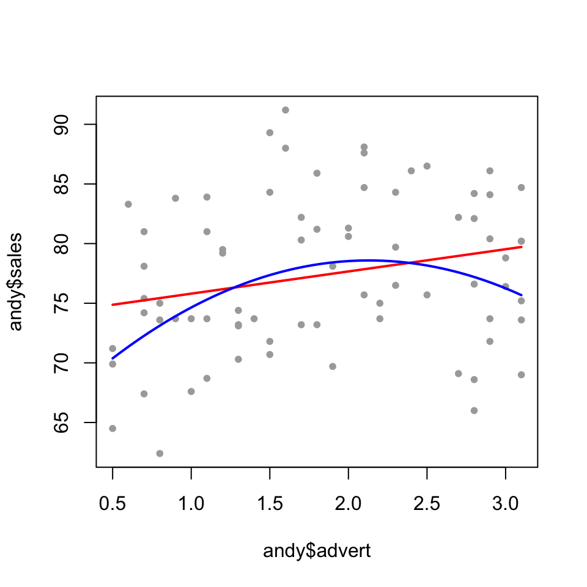

````
```
````

````
```{r,}
````

```r
plot(andy$advert, andy$sales, ylim = c(min(andy$sales), max(andy$sales)), pch = 20, col = "darkgray")
adv = seq(min(andy$advert), max(andy$advert), length.out = 100)
y = predict(mod1, data.frame(advert = adv, price = mean(andy$price)))
lines(adv, y, col = "red", lwd = 2)
y = predict(mod2.1, data.frame(advert = adv, price = mean(andy$price)))
lines(adv, y, col = "blue", lwd = 2)
```

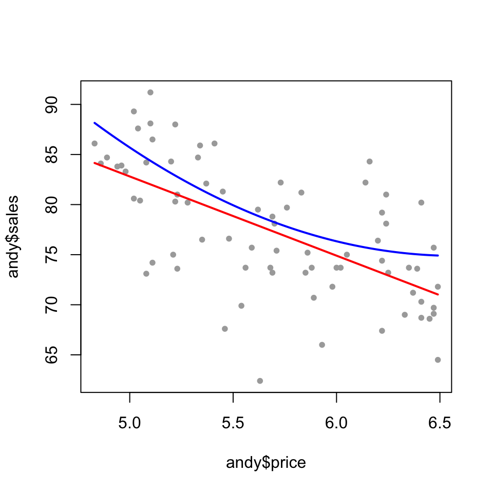

```r
plot(andy$price, andy$sales, ylim = c(min(andy$sales), max(andy$sales)), pch = 20, col = "darkgray")
prc = seq(min(andy$price), max(andy$price), length.out = 100)
y = predict(mod1, data.frame(advert = mean(andy$advert), price = prc))
lines(prc, y, col = "red", lwd = 2)
y = predict(mod2.1, data.frame(advert = mean(andy$advert), price = prc))
lines(prc, y, col = "blue", lwd = 2)
```

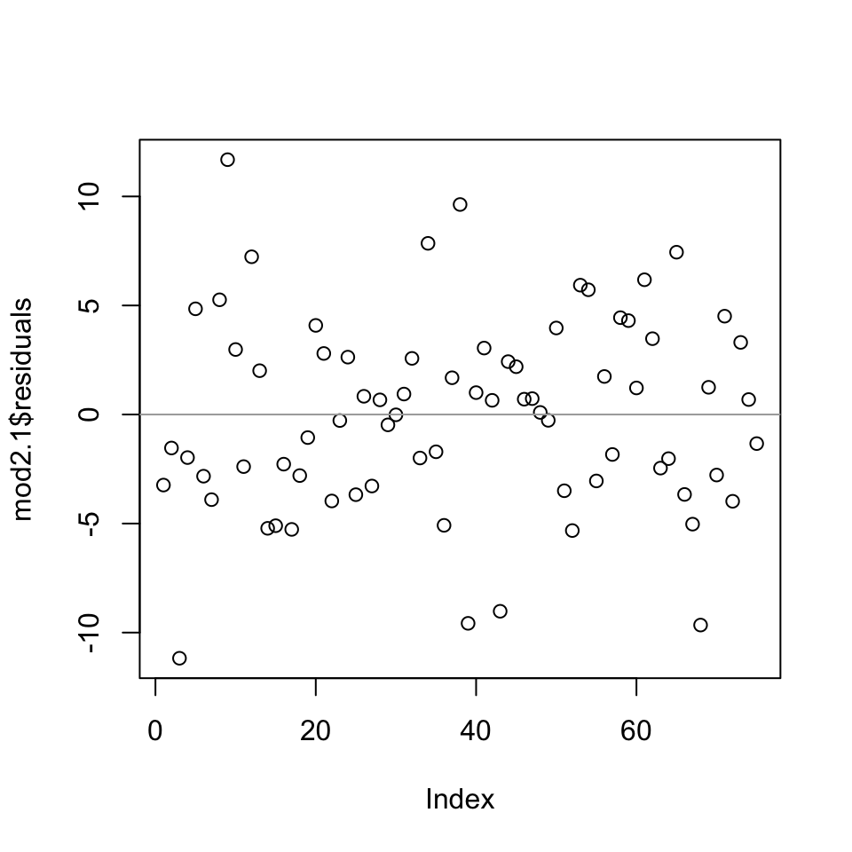

```r
plot(mod2.1$residuals); abline(h = 0, col = "darkgray")
```

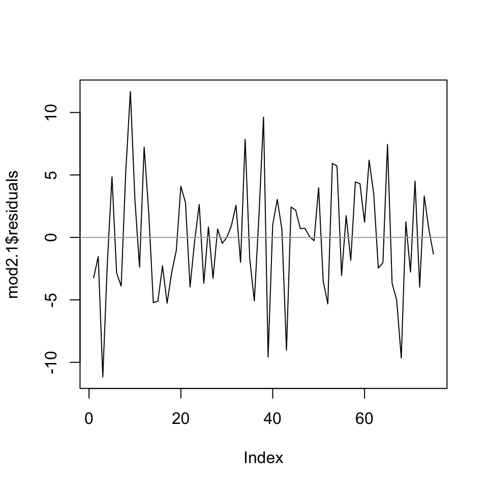

```r
plot(mod2.1$residuals, type = "l"); abline(h = 0, col = "darkgray")
```

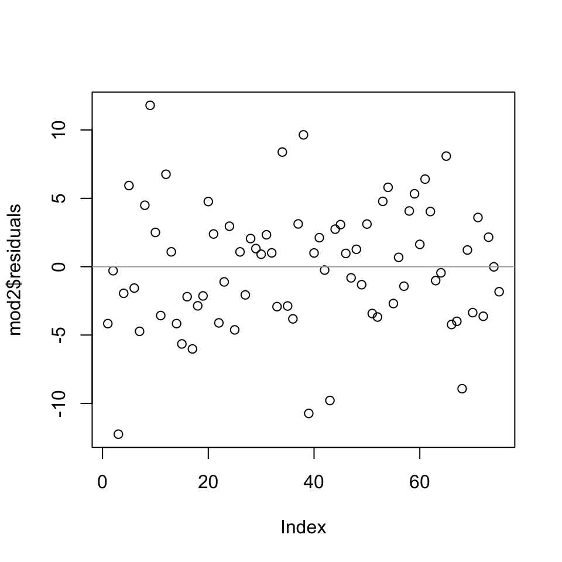

```r
plot(mod2$residuals); abline(h = 0, col = "darkgray")
```

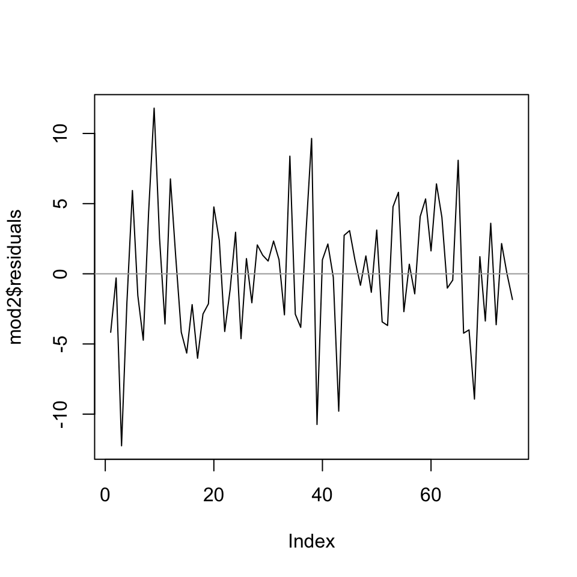

```r
plot(mod2$residuals, type = "l"); abline(h = 0, col = "darkgray")
```

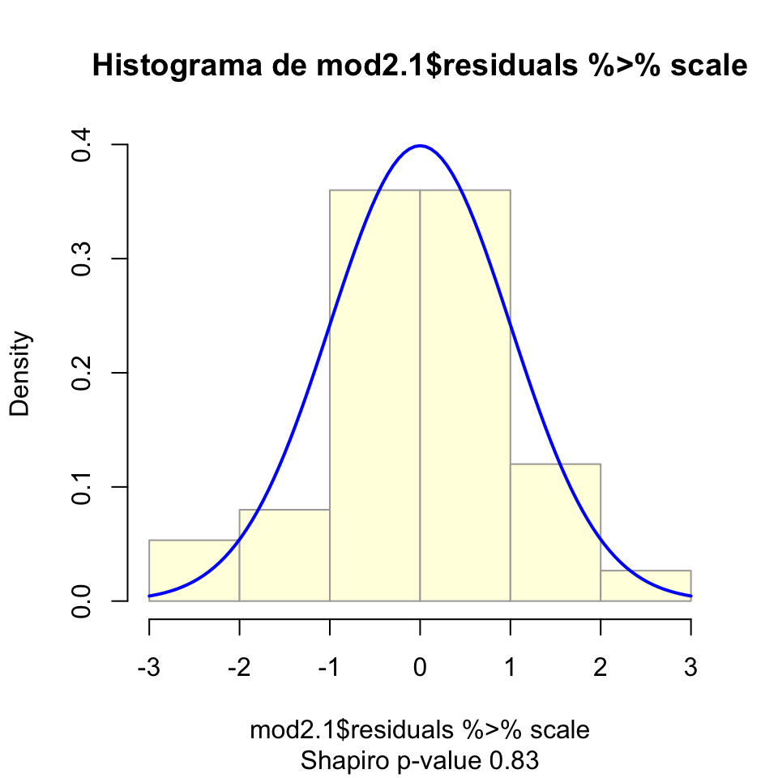

````
```
````

```r
mhist(mod2.1$residuals %>% scale, breaks = 6)
```

# AULA 5

````
```{r,}
````

```r
library(magrittr)
```

# 12 Chapter 7 Using Indicator Variables

## 12.1 7.1 Factor Variables

````
```{r,}
````

```r
library(stargazer); library(ggplot2)
data("utown", package="PoEdata")
utown %>% head
```

| price | sqft | age | utown | pool | fplace |
| --- | --- | --- | --- | --- | --- |
| 205.452 | 23.46 | 6 | 0 | 0 | 1 |
| 185.328 | 20.03 | 5 | 0 | 0 | 1 |
| 248.422 | 27.77 | 6 | 0 | 0 | 0 |
| 154.690 | 20.17 | 1 | 0 | 0 | 0 |
| 221.801 | 26.45 | 0 | 0 | 0 | 1 |
| 199.119 | 21.56 | 6 | 0 | 0 | 1 |

```r
utown$utown %>% as.factor() -> utown$utown
utown$pool %>% as.factor() -> utown$pool
utown$fplace %>% as.factor() -> utown$fplace
utown %>% head
```

| price | sqft | age | utown | pool | fplace |
| --- | --- | --- | --- | --- | --- |
| 205.452 | 23.46 | 6 | 0 | 0 | 1 |
| 185.328 | 20.03 | 5 | 0 | 0 | 1 |
| 248.422 | 27.77 | 6 | 0 | 0 | 0 |
| 154.690 | 20.17 | 1 | 0 | 0 | 0 |
| 221.801 | 26.45 | 0 | 0 | 0 | 1 |
| 199.119 | 21.56 | 6 | 0 | 0 | 1 |

````
```
````

````
```{r,}
````

```r
library(PoEdata)
?utown
```

| utown | R Documentation |
| --- | --- |

## Utown Data

### Description

Obs: 1000 observations

### Usage

```r
data("utown")
```

### Format

A data frame with 1000 observations on the following 6 variables.

**`price`**

house price, in $1000

**`sqft`**

square feet of living area, in 100's

**`age`**

house age, in years

**`utown`**

=1 if close to university

**`pool`**

=1 if house has pool

**`fplace`**

=1 if house has fireplace

### Source

http://principlesofeconometrics.com/poe4/poe4.htm

### Examples

```r
data(utown)
## maybe str(utown) ; plot(utown) ...
```

```r
mod4 <- lm(price~as.factor(utown)*sqft+age+as.factor(pool)+as.factor(fplace), data=utown)
summary(mod4)
```

```
##
## Call:
## lm(formula = price ~ as.factor(utown) * sqft + age + as.factor(pool) +
##     as.factor(fplace), data = utown)
##
## Residuals:
##     Min      1Q  Median      3Q     Max
## -50.289 -10.141   0.148  10.565  44.783
##
## Coefficients:
##                        Estimate Std. Error t value Pr(>|t|)
## (Intercept)             24.5000     6.1917   3.957 8.13e-05 ***
## as.factor(utown)1       27.4530     8.4226   3.259 0.001154 **
## sqft                     7.6122     0.2452  31.048  < 2e-16 ***
## age                     -0.1901     0.0512  -3.712 0.000217 ***
## as.factor(pool)1         4.3772     1.1967   3.658 0.000268 ***
## as.factor(fplace)1       1.6492     0.9720   1.697 0.090056 .
## as.factor(utown)1:sqft   1.2994     0.3321   3.913 9.72e-05 ***
## ---
## Signif. codes:  0 '***' 0.001 '**' 0.01 '*' 0.05 '.' 0.1 ' ' 1
##
## Residual standard error: 15.23 on 993 degrees of freedom
## Multiple R-squared:  0.8706, Adjusted R-squared:  0.8698
## F-statistic:  1113 on 6 and 993 DF,  p-value: < 2.2e-16
```

````
```
````

````
```{r,}
````

```r
data("cps4_small", package="PoEdata")
cps4_small %>% head
```

| wage | educ | exper | hrswk | married | female | metro | midwest | south | west | black | asian |
| --- | --- | --- | --- | --- | --- | --- | --- | --- | --- | --- | --- |
| 18.70 | 16 | 39 | 37 | 1 | 1 | 1 | 0 | 1 | 0 | 0 | 0 |
| 11.50 | 12 | 16 | 62 | 0 | 0 | 0 | 1 | 0 | 0 | 0 | 0 |
| 15.04 | 16 | 13 | 40 | 1 | 0 | 1 | 0 | 0 | 1 | 1 | 0 |
| 25.95 | 14 | 11 | 40 | 0 | 1 | 1 | 0 | 1 | 0 | 1 | 0 |
| 24.03 | 12 | 51 | 40 | 1 | 0 | 1 | 0 | 0 | 0 | 0 | 0 |
| 20.00 | 12 | 30 | 40 | 1 | 0 | 1 | 0 | 0 | 0 | 0 | 0 |

````
```
````

````
```{r,}
````

```r
mod5 <- lm(wage~educ+as.factor(black)*as.factor(female), data=cps4_small)
summary(mod5)
```

```
##
## Call:
## lm(formula = wage ~ educ + as.factor(black) * as.factor(female),
##     data = cps4_small)
##
## Residuals:
##     Min      1Q  Median      3Q     Max
## -27.162  -6.912  -2.845   4.901  57.470
##
## Coefficients:
##                                      Estimate Std. Error t value Pr(>|t|)
## (Intercept)                           -5.2812     1.9005  -2.779  0.00556 **
## educ                                   2.0704     0.1349  15.350  < 2e-16 ***
## as.factor(black)1                     -4.1691     1.7747  -2.349  0.01901 *
## as.factor(female)1                    -4.7846     0.7734  -6.186 8.98e-10 ***
## as.factor(black)1:as.factor(female)1   3.8443     2.3277   1.652  0.09894 .
## ---
## Signif. codes:  0 '***' 0.001 '**' 0.01 '*' 0.05 '.' 0.1 ' ' 1
##
## Residual standard error: 11.44 on 995 degrees of freedom
## Multiple R-squared:  0.2089, Adjusted R-squared:  0.2057
## F-statistic: 65.67 on 4 and 995 DF,  p-value: < 2.2e-16
```

````
```
````

````
```{r,}
````

```r
.stargazertype = "text"
dnosouth <- cps4_small[which(cps4_small$south==0),]#no south
dsouth <- cps4_small[which(cps4_small$south==1),] #south
mod5ns <- lm(wage~educ+black*female, data=dnosouth)
mod5s <- lm(wage~educ+black*female, data=dsouth)
mod6 <- lm(wage~educ+black*female+south/(educ+black*female),
                       data=cps4_small)
stargazer(mod6, mod5ns, mod5s, header=FALSE,
  type=.stargazertype,
  title="Model comparison, 'wage' equation",
  digits=2, single.row=TRUE, column.labels = c("Todo", "Não SUL", "SUL"),
  intercept.bottom=FALSE)
```

```
##
## Model comparison, 'wage' equation
## ========================================================================================
##                                             Dependent variable:
##                     --------------------------------------------------------------------
##                                                     wage
##                              Todo                 Não SUL                  SUL
##                              (1)                    (2)                    (3)
## ----------------------------------------------------------------------------------------
## Constant               -6.61*** (2.34)        -6.61*** (2.30)          -2.66 (3.42)
## educ                    2.17*** (0.17)         2.17*** (0.16)         1.86*** (0.24)
## black                   -5.09* (2.64)          -5.09* (2.60)           -3.38 (2.58)
## female                 -5.01*** (0.90)        -5.01*** (0.89)        -4.10*** (1.58)
## south                    3.94 (4.05)
## black:female             5.31 (3.50)            5.31 (3.45)            2.37 (3.38)
## educ:south               -0.31 (0.29)
## black:south              1.70 (3.63)
## female:south             0.90 (1.77)
## black:female:south       -2.94 (4.79)
## ----------------------------------------------------------------------------------------
## Observations                1,000                   704                    296
## R2                           0.21                   0.22                   0.18
## Adjusted R2                  0.20                   0.22                   0.17
## Residual Std. Error    11.46 (df = 990)       11.29 (df = 699)       11.85 (df = 291)
## F Statistic         29.26*** (df = 9; 990) 49.72*** (df = 4; 699) 16.43*** (df = 4; 291)
## ========================================================================================
## Note:                                                        *p<0.1; **p<0.05; ***p<0.01
```

````
```
````

````
```{r,}
````

```r
anova(mod5, mod6)
```

| Res.Df | RSS | Df | Sum of Sq | F | Pr(>F) |
| --- | --- | --- | --- | --- | --- |
| 995 | 130194.7 | NA | NA | NA | NA |
| 990 | 129984.4 | 5 | 210.2582 | 0.3202779 | 0.9009447 |

````
```
````

## 12.2 7.5 The Linear Probability Model

````
```{r,}
````

```r
data("coke", package="PoEdata")
coke %>% head
```

| coke | pr_pepsi | pr_coke | disp_pepsi | disp_coke | pratio |
| --- | --- | --- | --- | --- | --- |
| 1 | 1.79 | 1.79 | 0 | 0 | 1.000000 |
| 1 | 1.79 | 0.89 | 0 | 1 | 0.497207 |
| 1 | 1.41 | 0.89 | 0 | 0 | 0.631206 |
| 1 | 1.79 | 1.33 | 0 | 0 | 0.743017 |
| 1 | 1.79 | 1.79 | 0 | 0 | 1.000000 |
| 1 | 0.99 | 1.79 | 1 | 0 | 1.808081 |

```r
mod2 <- lm(coke~pratio+disp_coke+disp_pepsi, data=coke)
summary(mod2)
```

```
##
## Call:
## lm(formula = coke ~ pratio + disp_coke + disp_pepsi, data = coke)
##
## Residuals:
##     Min      1Q  Median      3Q     Max
## -0.7681 -0.4186 -0.1560  0.4547  1.2073
##
## Coefficients:
##             Estimate Std. Error t value Pr(>|t|)
## (Intercept)  0.89022    0.06548  13.594  < 2e-16 ***
## pratio      -0.40086    0.06135  -6.534 9.64e-11 ***
## disp_coke    0.07717    0.03439   2.244    0.025 *
## disp_pepsi  -0.16566    0.03560  -4.654 3.65e-06 ***
## ---
## Signif. codes:  0 '***' 0.001 '**' 0.01 '*' 0.05 '.' 0.1 ' ' 1
##
## Residual standard error: 0.4672 on 1136 degrees of freedom
## Multiple R-squared:  0.1201, Adjusted R-squared:  0.1177
## F-statistic: 51.67 on 3 and 1136 DF,  p-value: < 2.2e-16
```

````
```
````

## 12.3 7.7 The Difference-in-Differences Estimator

$$y_{i,t} = b_0 + b_1T + b_2A +\delta (T \times A) + e_{i,t}$$

````
```{r,}
````

```r
data("njmin3", package="PoEdata")
njmin3 %>% head
```

| nj | d | d_nj | fte | bk | kfc | roys | wendys | co_owned | centralj | southj | pa1 | pa2 | demp |
| --- | --- | --- | --- | --- | --- | --- | --- | --- | --- | --- | --- | --- | --- |
| 1 | 0 | 0 | 15.00 | 1 | 0 | 0 | 0 | 0 | 1 | 0 | 0 | 0 | 12.00 |
| 1 | 0 | 0 | 15.00 | 1 | 0 | 0 | 0 | 0 | 1 | 0 | 0 | 0 | 6.50 |
| 1 | 0 | 0 | 24.00 | 0 | 0 | 1 | 0 | 0 | 1 | 0 | 0 | 0 | -1.00 |
| 1 | 0 | 0 | 19.25 | 0 | 0 | 1 | 0 | 1 | 0 | 0 | 0 | 0 | 2.25 |
| 1 | 0 | 0 | 21.50 | 1 | 0 | 0 | 0 | 0 | 0 | 0 | 0 | 0 | 13.00 |
| 1 | 0 | 0 | 9.50 | 0 | 1 | 0 | 0 | 0 | 0 | 0 | 0 | 0 | 1.00 |

```r
mod1 <- lm(fte~nj*d, data=njmin3)
summary(mod1)
```

```
##
## Call:
## lm(formula = fte ~ nj * d, data = njmin3)
##
## Residuals:
##     Min      1Q  Median      3Q     Max
## -21.166  -6.439  -1.027   4.473  64.561
##
## Coefficients:
##             Estimate Std. Error t value Pr(>|t|)
## (Intercept)   23.331      1.072  21.767   <2e-16 ***
## nj            -2.892      1.194  -2.423   0.0156 *
## d             -2.166      1.516  -1.429   0.1535
## nj:d           2.754      1.688   1.631   0.1033
## ---
## Signif. codes:  0 '***' 0.001 '**' 0.01 '*' 0.05 '.' 0.1 ' ' 1
##
## Residual standard error: 9.406 on 790 degrees of freedom
##   (26 observations deleted due to missingness)
## Multiple R-squared:  0.007401,   Adjusted R-squared:  0.003632
## F-statistic: 1.964 on 3 and 790 DF,  p-value: 0.118
```

```r
mod2 <- lm(fte~nj*d+kfc+roys+wendys+co_owned, data=njmin3)
summary(mod2)
```

```
##
## Call:
## lm(formula = fte ~ nj * d + kfc + roys + wendys + co_owned, data = njmin3)
##
## Residuals:
##     Min      1Q  Median      3Q     Max
## -24.196  -5.075  -1.196   3.272  64.219
##
## Coefficients:
##             Estimate Std. Error t value Pr(>|t|)
## (Intercept)  25.9512     1.0382  24.996   <2e-16 ***
## nj           -2.3766     1.0792  -2.202   0.0279 *
## d            -2.2236     1.3677  -1.626   0.1044
## kfc         -10.4534     0.8490 -12.313   <2e-16 ***
## roys         -1.6250     0.8598  -1.890   0.0591 .
## wendys       -1.0637     0.9292  -1.145   0.2526
## co_owned     -1.1685     0.7162  -1.632   0.1032
## nj:d          2.8451     1.5233   1.868   0.0622 .
## ---
## Signif. codes:  0 '***' 0.001 '**' 0.01 '*' 0.05 '.' 0.1 ' ' 1
##
## Residual standard error: 8.484 on 786 degrees of freedom
##   (26 observations deleted due to missingness)
## Multiple R-squared:  0.1964, Adjusted R-squared:  0.1893
## F-statistic: 27.45 on 7 and 786 DF,  p-value: < 2.2e-16
```

```r
mod3 <- lm(fte~nj*d+kfc+roys+wendys+co_owned+southj+centralj+pa1, data=njmin3)
summary(mod3)
```

```
##
## Call:
## lm(formula = fte ~ nj * d + kfc + roys + wendys + co_owned +
##     southj + centralj + pa1, data = njmin3)
##
## Residuals:
##     Min      1Q  Median      3Q     Max
## -25.016  -4.964  -1.036   3.251  62.989
##
## Coefficients:
##               Estimate Std. Error t value Pr(>|t|)
## (Intercept)  25.320513   1.210903  20.910  < 2e-16 ***
## nj           -0.907964   1.271742  -0.714   0.4755
## d            -2.211851   1.348860  -1.640   0.1014
## kfc         -10.058002   0.844671 -11.908  < 2e-16 ***
## roys         -1.693393   0.859184  -1.971   0.0491 *
## wendys       -1.064952   0.920638  -1.157   0.2477
## co_owned     -0.716310   0.718990  -0.996   0.3194
## southj       -3.701761   0.779953  -4.746 2.46e-06 ***
## centralj      0.007883   0.897494   0.009   0.9930
## pa1           0.923862   1.384928   0.667   0.5049
## nj:d          2.814908   1.502382   1.874   0.0614 .
## ---
## Signif. codes:  0 '***' 0.001 '**' 0.01 '*' 0.05 '.' 0.1 ' ' 1
##
## Residual standard error: 8.367 on 783 degrees of freedom
##   (26 observations deleted due to missingness)
## Multiple R-squared:  0.2214, Adjusted R-squared:  0.2115
## F-statistic: 22.26 on 10 and 783 DF,  p-value: < 2.2e-16
```

````
```
````

# Trabalho

## 12.4 Questão 1

````
```{r,}
````

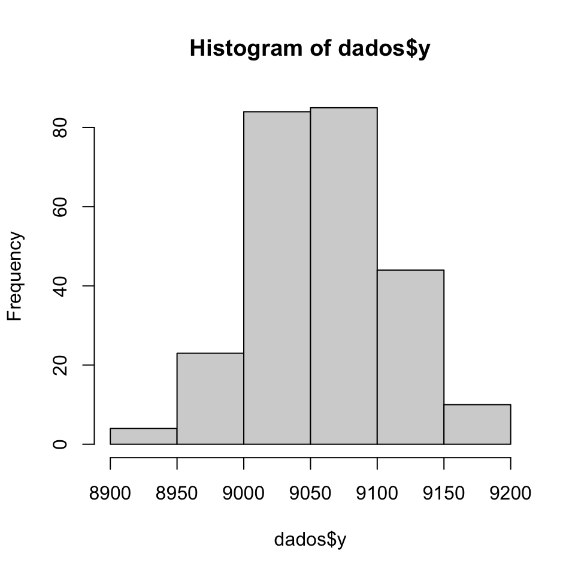

```r
library(openxlsx)
#file.choose()
dados <- read.xlsx("/Users/jfrega/Downloads/ExerciciosAula05.xlsx", sheet = "Q1")
# Examinando a variável dependente (parece OK)
hist(dados$y)
```

```r
# Fazendo o gráfico de dispersão
# A relação não parece ser linear
plot(dados$x, dados$y, pch = 20, col = "darkgray")
# modelo linear
m.1.q1 = lm(y~x, data = dados)
library(lmtest)
# teste de forma funcional
# p-valor < 0.05 = forma funcional inadequada
reset(m.1.q1)
```

```
##
##  RESET test
##
## data:  m.1.q1
## RESET = 31.63, df1 = 2, df2 = 246, p-value = 5.961e-13
```

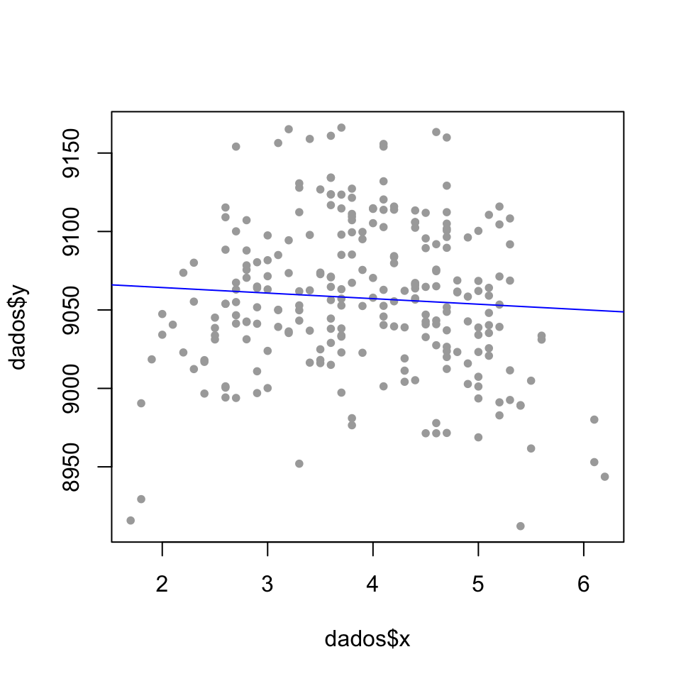

```r
plot(dados$x, dados$y, pch = 20, col = "darkgray")
abline(m.1.q1, col = "blue")
```

```r
# testando forma quadrática
m.2.q1 = lm(y~x+I(x^2), data = dados)
# teste de forma funcional
# p-valor > 0.05 = forma funcional adequada
reset(m.2.q1)
```

```
##
##  RESET test
##
## data:  m.2.q1
## RESET = 0.16152, df1 = 2, df2 = 245, p-value = 0.8509
```

```r
# teste de normalidade dos resíduos
# p-valor > 0.05 = resíduos são normais
shapiro.test(m.2.q1$residuals)
```

```
##
##  Shapiro-Wilk normality test
##
## data:  m.2.q1$residuals
## W = 0.99586, p-value = 0.7466
```

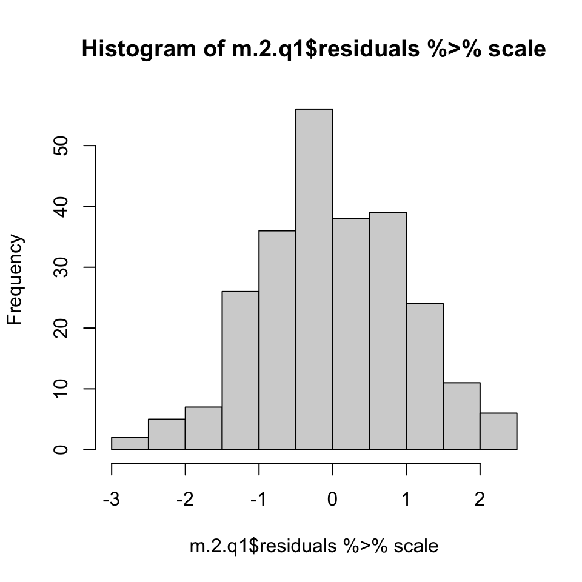

```r
hist(m.2.q1$residuals %>% scale)
```

```r
# teste de heteroscedasticidade
# p-valor > 0.05 = dados são homoscedásticos
bptest(m.2.q1)
```

```
##
##  studentized Breusch-Pagan test
##
## data:  m.2.q1
## BP = 1.5566, df = 2, p-value = 0.4592
```

````
```
````

O modelo mais adequado é

$$y = b_0+b_1x+b_2x^2+e$$

````
```{r,}
````

```r
summary(m.2.q1)
```

```
##
## Call:
## lm(formula = y ~ x + I(x^2), data = dados)
##
## Residuals:
##      Min       1Q   Median       3Q      Max
## -120.515  -30.442   -2.504   30.633  101.440
##
## Coefficients:
##             Estimate Std. Error t value Pr(>|t|)
## (Intercept) 8771.778     39.414 222.553  < 2e-16 ***
## x            162.072     21.025   7.709 3.11e-13 ***
## I(x^2)       -21.497      2.703  -7.952 6.58e-14 ***
## ---
## Signif. codes:  0 '***' 0.001 '**' 0.01 '*' 0.05 '.' 0.1 ' ' 1
##
## Residual standard error: 43.08 on 247 degrees of freedom
## Multiple R-squared:  0.2077, Adjusted R-squared:  0.2013
## F-statistic: 32.38 on 2 and 247 DF,  p-value: 3.246e-13
```

````
```
````

````
```{r,}
````

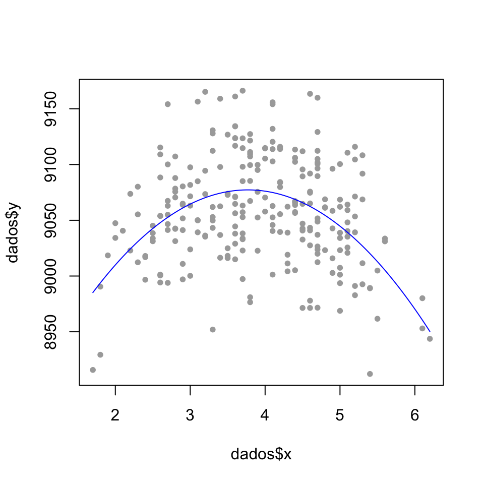

````
```
````

```r
plot(dados$x, dados$y, pch = 20, col = "darkgray")
.x = seq(min(dados$x), max(dados$x), length.out = 100)
.y = predict(m.2.q1, data.frame(x = .x))
lines(.x, .y, col = "blue")
```

## 12.5 Questão 2

````
```{r,}
````

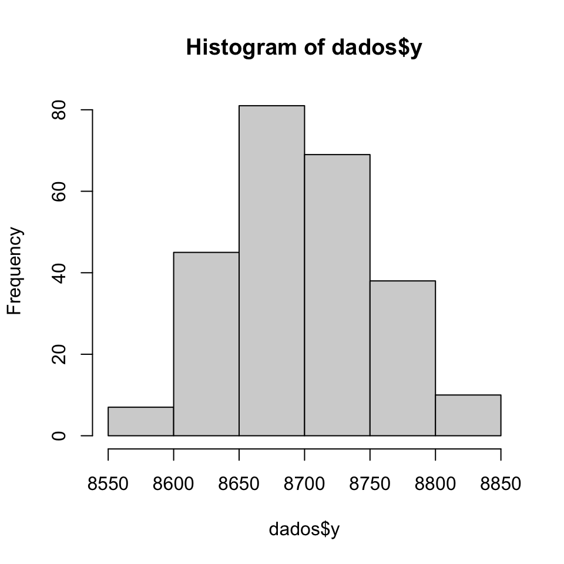

```r
dados <- read.xlsx("/Users/jfrega/Downloads/ExerciciosAula05.xlsx", sheet = "Q2")
# Examinando a variável dependente (parece OK)
hist(dados$y)
```

```r
# Fazendo o gráfico de dispersão
# A relação não parece ser linear
plot(dados$x, dados$y, pch = 20, col = "darkgray")
# modelo linear
m.1.q2 = lm(y~x, data = dados)
library(lmtest)
# teste de forma funcional
# p-valor < 0.05 = forma funcional inadequada
reset(m.1.q2)
```

```
##
##  RESET test
##
## data:  m.1.q2
## RESET = 8.1831, df1 = 2, df2 = 246, p-value = 0.0003625
```

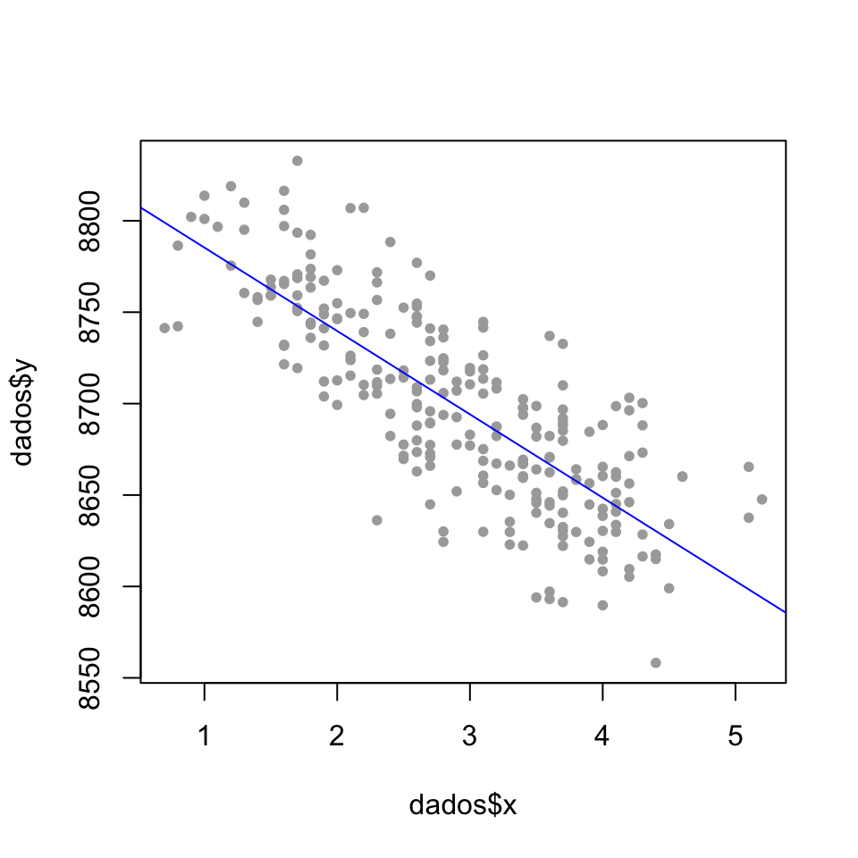

```r
plot(dados$x, dados$y, pch = 20, col = "darkgray")
abline(m.1.q2, col = "blue")
```

```r
# testando forma quadrática
m.2.q2 = lm(y~x+I(x^2), data = dados)
# teste de forma funcional
# p-valor < 0.05 = forma funcional inadequada
reset(m.2.q2)
```

```
##
##  RESET test
##
## data:  m.2.q2
## RESET = 5.723, df1 = 2, df2 = 245, p-value = 0.003723
```

```r
# testando forma cúbica
m.3.q2 = lm(y~x+I(x^2)+I(x^3), data = dados)
# teste de forma funcional
# p-valor > 0.05 = forma funcional adequada
reset(m.3.q2)
```

```
##
##  RESET test
##
## data:  m.3.q2
## RESET = 0.79521, df1 = 2, df2 = 244, p-value = 0.4527
```

```r
# teste de normalidade dos resíduos
# p-valor > 0.05 = resíduos são normais
shapiro.test(m.3.q2$residuals)
```

```
##
##  Shapiro-Wilk normality test
##
## data:  m.3.q2$residuals
## W = 0.99525, p-value = 0.6366
```

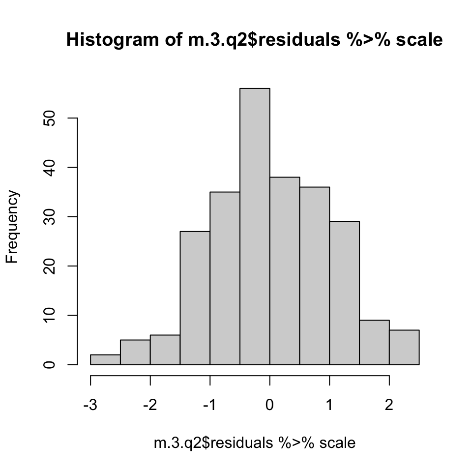

```r
hist(m.3.q2$residuals %>% scale)
```

```r
# teste de heteroscedasticidade
# p-valor > 0.05 = dados são homoscedásticos
bptest(m.3.q2)
```

```
##
##  studentized Breusch-Pagan test
##
## data:  m.3.q2
## BP = 2.2443, df = 3, p-value = 0.5233
```

````
```
````

````
```{r,}
````

```r
summary(m.3.q2)
```

```
##
## Call:
## lm(formula = y ~ x + I(x^2) + I(x^3), data = dados)
##
## Residuals:
##     Min      1Q  Median      3Q     Max
## -92.606 -23.342  -1.602  23.448  77.099
##
## Coefficients:
##             Estimate Std. Error t value Pr(>|t|)
## (Intercept) 8771.642     33.168 264.457  < 2e-16 ***
## x             46.522     38.610   1.205  0.22939
## I(x^2)       -40.319     14.005  -2.879  0.00434 **
## I(x^3)         5.215      1.599   3.261  0.00127 **
## ---
## Signif. codes:  0 '***' 0.001 '**' 0.01 '*' 0.05 '.' 0.1 ' ' 1
##
## Residual standard error: 32.4 on 246 degrees of freedom
## Multiple R-squared:  0.652,  Adjusted R-squared:  0.6478
## F-statistic: 153.6 on 3 and 246 DF,  p-value: < 2.2e-16
```

````
```
````

````
```{r,}
````

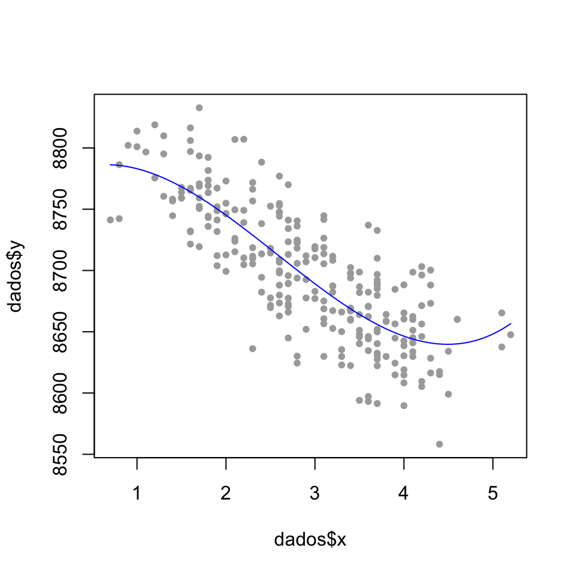

````
```
````

````
```{r,}
````

```r
plot(dados$x, dados$y, pch = 20, col = "darkgray")
.x = seq(min(dados$x), max(dados$x), length.out = 100)
.y = predict(m.3.q2, data.frame(x = .x))
lines(.x, .y, col = "blue")
```

```r
library(broom)
glance(m.1.q2)$AIC
```

```
## [1] 2466.691
```

```r
glance(m.2.q2)$AIC
```

```
## [1] 2463.17
```

```r
glance(m.3.q2)$AIC
```

```
## [1] 2454.589
```

```r
glance(m.1.q2)$BIC
```

```
## [1] 2477.256
```

```r
glance(m.2.q2)$BIC
```

```
## [1] 2477.256
```

```r
glance(m.3.q2)$BIC
```

```
## [1] 2472.196
```

```r
anova(m.1.q2, m.2.q2, m.3.q2)
```

| Res.Df | RSS | Df | Sum of Sq | F | Pr(>F) |
| --- | --- | --- | --- | --- | --- |
| 248 | 275501.8 | NA | NA | NA | NA |
| 247 | 269483.7 | 1 | 6018.098 | 5.731162 | 0.0174162 |
| 246 | 258316.2 | 1 | 11167.527 | 10.635072 | 0.0012666 |

````
```
````

## 12.6 Questão 3

````
```{r,}
````

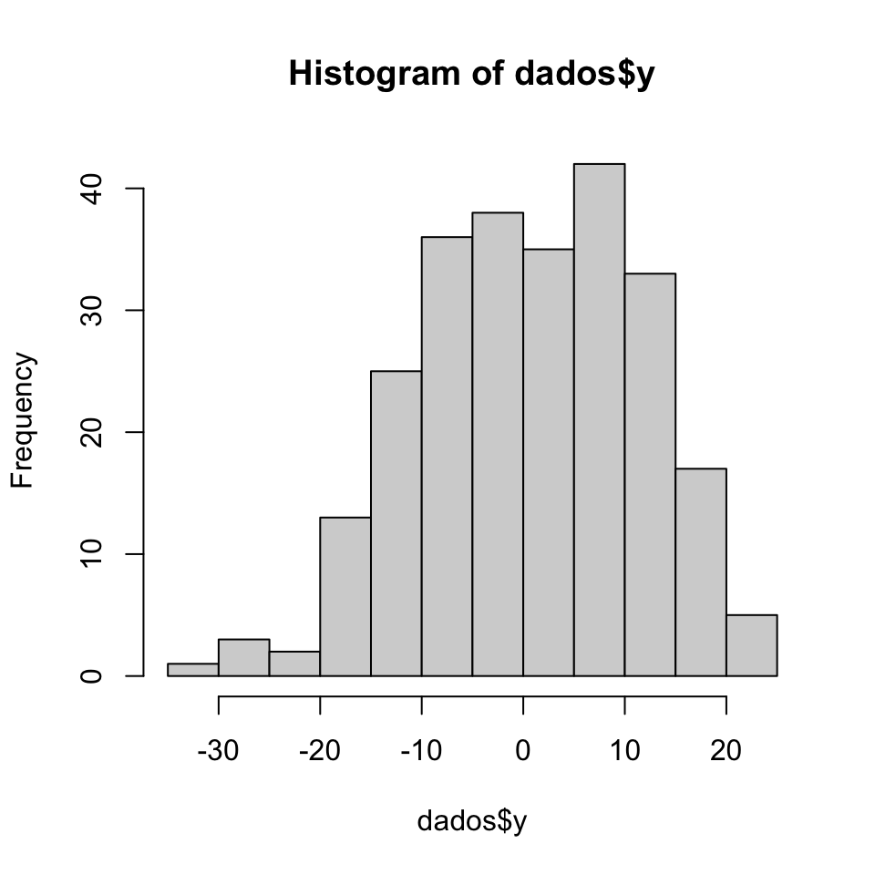

```r
dados <- read.xlsx("/Users/jfrega/Downloads/ExerciciosAula05.xlsx", sheet = "Q3")
# Examinando a variável dependente (parece OK)
hist(dados$y)
```

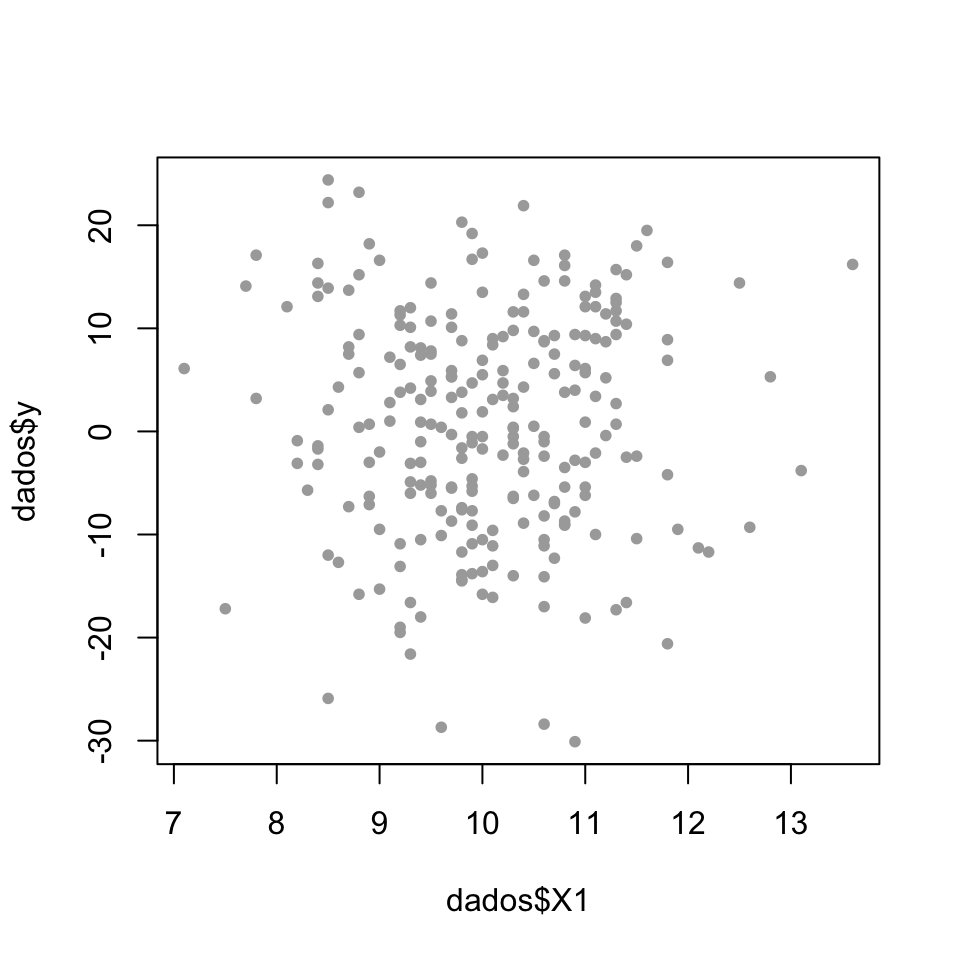

```r
# Fazendo o gráfico de dispersão
# A relação não parece ser linear
layout(c(1, 2, 3) %>% matrix(nrow = 1))
layout(1)
plot(dados$X1, dados$y, pch = 20, col = "darkgray")
```

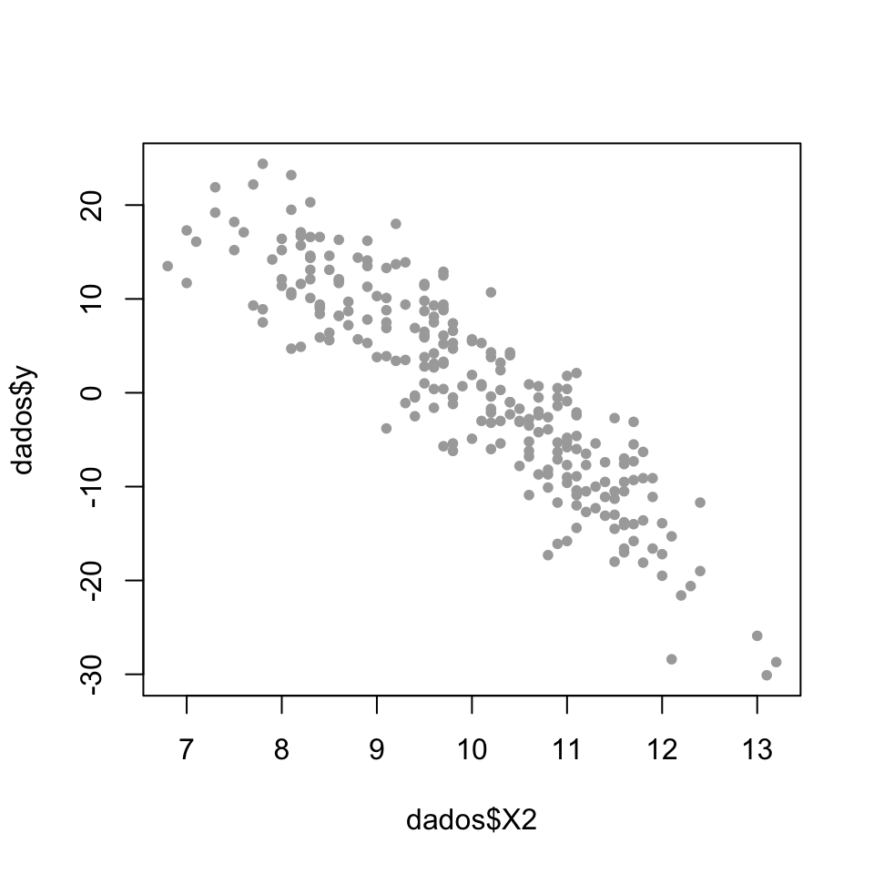

```r
plot(dados$X2, dados$y, pch = 20, col = "darkgray")
```